# Analysing Sentences Backbone Communities

Published

November 29, 2025

```r
source(here::here("scripts", "paths_and_packages.R"))
p_load(see, kableExtra, DT, ggiraph)

metadata_jstor <- read_rds(file.path(
  jstor_data_path,
  "jstor_constellate_merged_metadata.rds"
)) %>%
  filter(
    refined_sub_type == "research-article",
    languages == "eng",
    publication_year < 2010,
    to_keep,
  ) %>%
  select(
    id = url,
    journal = is_part_of,
    title,
    authors = creators_string,
    year = publication_year,
    ID_Art = id_wos_matched
  ) %>%
  mutate(url = id) |>
  arrange(year)

# same for scopus metadata
metadata_scopus <- read_rds(file.path(
  elsevier_data_path,
  "scopus_economics_articles.rds"
)) %>%
  mutate(
    year = as.integer(str_sub(prism_cover_date, 1, 4)),
    url = str_c("doi.org/", prism_doi)
  ) %>%
  filter(
    full_text == TRUE,
    subtype_description == "Article",
    year < 2010
  ) %>%
  select(
    id = scopus_id,
    title = dc_title,
    authors = dc_creator,
    journal = prism_publication_name,
    year,
    url,
    ID_Art = id_wos_matched
  )

nb_sentences <- read_feather(file.path(
  data_path,
  "n_sentences_per_id_after_cleaning.feather"
))

metadata <- bind_rows(metadata_jstor, metadata_scopus) |>
  filter(!is.na(year) & !is.na(title)) %>%
  left_join(nb_sentences, by = "id")

sentences_dataset <- open_dataset(
  file.path(
    data_path,
    "sentences_intertemporal_cluster.feather"
  ),
  format = "feather"
)

sentences <- sentences_dataset %>%
  filter(between(year, 1900, 2009)) %>%
  select(
    id,
    sentence_id,
    cluster_id,
    HDBSCAN_cluster,
    window,
    backbone_community,
    sentence,
    similarity_rv,
    embedding
  ) %>%
  collect() %>%
  inner_join(metadata, by = "id") %>%
  arrange(id, sentence_id)
setDT(sentences)

rm(metadata, metadata_jstor, metadata_scopus)
gc()

# Adding references
sentences_art <- sentences[
  !is.na(ID_Art),
  .N,
  .(id, HDBSCAN_cluster, window, backbone_community, ID_Art)
]
setnames(sentences_art, "N", "nb_sentence")

data_ref <- open_dataset(
  here::here(wos_data_path, "all_ref.parquet"),
  format = "parquet"
)
refs <- data_ref %>%
  filter(ID_Art %in% unique(sentences_art$ID_Art)) %>%
  distinct(ID_Art, ItemID_Ref, Annee, Nom, Revue_Abbrege) %>%
  collect()

backbone_network <- read_rds(file.path(
  data_path,
  "backbone_network_of_sentences_clusters.rds"
)) |>
  filter(window != "2010-2019") # we don't have sentences from 2010 onward

list_clusters <- sentences %>%
  pull(backbone_community) %>%
  unique() |>
  sort()
```

```r
top_refs <- sentences_art %>%
  left_join(refs, by = "ID_Art", relationship = "many-to-many") %>%
  filter(ItemID_Ref != 0) %>%
  group_by(
    HDBSCAN_cluster,
    window,
    backbone_community,
    ItemID_Ref,
    nb_sentence
  ) %>%
  summarise(absolute_cluster_cit = n(), .groups = "drop") %>%
  mutate(weighted_cluster_cit = absolute_cluster_cit * nb_sentence) %>%
  arrange(
    backbone_community,
    HDBSCAN_cluster,
    window,
    desc(weighted_cluster_cit)
  ) %>%
  group_by(backbone_community, HDBSCAN_cluster, window) %>%
  slice_head(n = 20) %>%
  ungroup() %>%
  filter(weighted_cluster_cit > 1) %>%
  left_join(
    refs %>% distinct(ItemID_Ref, Nom, Annee, Revue_Abbrege),
    by = "ItemID_Ref",
    relationship = "many-to-many"
  ) %>%
  distinct(
    backbone_community,
    HDBSCAN_cluster,
    window,
    ItemID_Ref,
    absolute_cluster_cit,
    weighted_cluster_cit,
    .keep_all = TRUE
  ) %>%
  mutate(
    absolute_cit = sum(absolute_cluster_cit),
    all_sentences = sum(nb_sentence),
    weighted_cit = absolute_cit * all_sentences,
    .by = c(ItemID_Ref, backbone_community)
  )

top_refs_without_id <- sentences_art %>%
  left_join(refs, by = "ID_Art", relationship = "many-to-many") %>%
  filter(ItemID_Ref == 0 & Annee != 0 & Nom != "") %>%
  group_by(backbone_community, HDBSCAN_cluster, window, Nom, Annee) %>%
  mutate(
    absolute_cluster_cit = n(),
    weighted_cluster_cit = absolute_cluster_cit * nb_sentence
  ) %>%
  filter(weighted_cluster_cit > 1) %>%
  distinct(
    ID_Art,
    backbone_community,
    HDBSCAN_cluster,
    window,
    .keep_all = TRUE
  ) %>%
  arrange(
    backbone_community,
    HDBSCAN_cluster,
    window,
    desc(weighted_cluster_cit)
  ) %>%
  group_by(backbone_community, HDBSCAN_cluster, window) %>%
  slice_head(n = 20) %>%
  ungroup() %>%
  select(
    backbone_community,
    HDBSCAN_cluster,
    window,
    Nom,
    Annee,
    Revue_Abbrege,
    nb_sentence,
    absolute_cluster_cit,
    weighted_cluster_cit
  ) %>%
  distinct(
    backbone_community,
    HDBSCAN_cluster,
    window,
    Nom,
    Annee,
    .keep_all = TRUE
  ) %>%
  mutate(
    absolute_cit = sum(absolute_cluster_cit),
    all_sentences = sum(nb_sentence),
    weighted_cit = absolute_cit * all_sentences,
    .by = c(Nom, Annee, Revue_Abbrege, backbone_community)
  )

rm(refs)
```

```r
recurring_authors <- sentences[
  !is.na(authors),
  .(authors = unlist(strsplit(authors, ",\\s+"))),
  by = .(id, sentence_id, backbone_community, HDBSCAN_cluster, window)
][, authors := trimws(authors)][
  !str_detect(authors, "^(?:<suffix>)?Jr\\.?(?:</suffix>)?$")
][,
  .(
    nb_sentences = .N,
    nb_articles = uniqueN(id)
  ),
  by = .(backbone_community, HDBSCAN_cluster, window, authors)
][order(-nb_sentences)][nb_sentences > 1][,
  head(.SD, 6),
  by = .(backbone_community, HDBSCAN_cluster, window)
]
```

```r
tokens <- extract_ngrams(
  sentences[, .(
    sentence,
    window,
    HDBSCAN_cluster,
    backbone_community
  )],
  ngrams = 2L,
  grouping_cols = c(
    "HDBSCAN_cluster",
    "backbone_community",
    "window"
  ),
  text_col = "sentence",
)

tokens_count_hdbscan_cluster <- compute_tf_idf(
  tokens,
  token_col = "token",
  document_col = c("backbone_community", "HDBSCAN_cluster", "window")
)

# Apply function to get threshold per (backbone_community, HDBSCAN_cluster, window)
top_terms_hdbscan_cluster <- filter_group_quantile(
  tokens_count_hdbscan_cluster,
  group_cols = c("backbone_community", "HDBSCAN_cluster", "window"),
  metric = "tf",
  probs = 0.75
)

# Top tf-idf terms
top_terms_hdbscan_cluster <- top_terms_hdbscan_cluster[order(-tf_idf)][,
  head(.SD, 15),
  by = .(backbone_community, HDBSCAN_cluster, window)
]

# Labels per decade
labels_hdbscan_cluster <- top_terms_hdbscan_cluster[order(-tf_idf)][,
  head(.SD, 5),
  by = .(backbone_community, HDBSCAN_cluster, window)
]

labels_hdbscan_cluster <- labels_hdbscan_cluster[,
  .(label_hdbscan_cluster = paste0(token, collapse = ", ")),
  by = .(backbone_community, HDBSCAN_cluster, window)
]

labels_hdbscan_cluster[,
  label_hdbscan_cluster := paste0(
    backbone_community,
    "_",
    HDBSCAN_cluster,
    "_",
    window,
    ": ",
    label_hdbscan_cluster
  ) # we save the backbonne community number to see difference in top terms depending on hdbscan cluster
]

sentences <- merge(
  sentences,
  labels_hdbscan_cluster,
  all.x = TRUE,
  by = c("backbone_community", "HDBSCAN_cluster", "window")
)

rm(tokens)
```

```r
tfidf_mean_community <- top_terms_hdbscan_cluster[,
  .(mean_tf_idf = mean(tf_idf)),
  by = .(token, backbone_community)
][order(-mean_tf_idf)]

# Top tf-idf terms
top_terms_cluster <- tfidf_mean_community[,
  head(.SD, 20),
  by = backbone_community
]

# Get top 4 tf-idf tokens per cluster
labels_backbone_community <- tfidf_mean_community[,
  head(.SD, 4),
  by = backbone_community
][, .(backbone_community, token)]
labels_backbone_community <- labels_backbone_community[,
  .(label_backbone_community = paste0(token, collapse = ", ")),
  by = backbone_community
]
labels_backbone_community[,
  label_backbone_community := paste0(
    str_extract(backbone_community, "\\d+$"),
    ": ",
    label_backbone_community
  )
]

sentences <- merge(
  sentences,
  labels_backbone_community,
  all.x = TRUE,
  by = "backbone_community"
)
```

```r
# Here, we find the sentences the closest to "rational" and "rationality" per hdbscan cluster
# We would then be able to extract the closest per backbone community later on
top_sentences_rationality <- sentences %>%
  select(
    id,
    sentence_id,
    sentence,
    similarity = similarity_rv,
    year,
    window,
    backbone_community,
    HDBSCAN_cluster
  ) %>%
  group_by(HDBSCAN_cluster, window) %>%
  slice_max(similarity, n = 20) %>%
  ungroup() %>%
  mutate(similarity = round(similarity, 3))
```

```r
# compute centroid (mean embedding) per backbone_community and attach to sentences,
# then compute cosine similarity of each sentence to its backbone centroid

# 1) centroid per community: bind embeddings into a matrix then colMeans
hdbscan_centroids <- sentences[,
  {
    m <- do.call(rbind, embedding) # matrix: rows = sentences in group
    list(hdbscan_centroid = list(colMeans(m))) # store centroid as a list-column
  },
  by = .(HDBSCAN_cluster, backbone_community)
]

# 2) merge centroids back into sentences (preserve sentence_id order)
similarities <- merge(
  sentences[, .(
    id,
    sentence_id,
    HDBSCAN_cluster,
    backbone_community,
    embedding
  )],
  hdbscan_centroids,
  by = c("HDBSCAN_cluster", "backbone_community"),
  all.x = TRUE
)
setorder(similarities, id, sentence_id)

# 3) cosine similarity between each sentence embedding and its community centroid
similarities[,
  similarity_hdbscan_centroid := map2_dbl(
    embedding,
    hdbscan_centroid,
    ~ {
      num <- sum(.x * .y)
      den <- sqrt(sum(.x * .x)) * sqrt(sum(.y * .y))
      if (den == 0) NA_real_ else num / den
    }
  )
]

# optional: round similarity for display
similarities[,
  similarity_hdbscan_centroid := round(similarity_hdbscan_centroid, 3)
]

# Merging back to sentences
sentences <- merge(
  sentences,
  similarities[, .(
    id,
    sentence_id,
    similarity_hdbscan_centroid
  )],
  by = c("id", "sentence_id"),
  all.x = TRUE
)

# Select the top 20 sentences for each backbone community
top_sentences_hdbscan_cluster_centroid <- sentences[, .(
  id,
  sentence_id,
  sentence,
  backbone_community,
  HDBSCAN_cluster,
  window,
  similarity_hdbscan_centroid
)]
top_sentences_hdbscan_cluster_centroid <- top_sentences_hdbscan_cluster_centroid[order(
  -similarity_hdbscan_centroid
)][,
  head(.SD, 10),
  by = .(backbone_community, HDBSCAN_cluster, window)
]

rm(similarities)
gc()
```

```r
# compute centroid (mean embedding) per backbone_community and attach to sentences,
# then compute cosine similarity of each sentence to its backbone centroid

# 1) centroid per community: bind embeddings into a matrix then colMeans
backbone_centroids <- hdbscan_centroids[,
  {
    m <- do.call(rbind, hdbscan_centroid) # matrix: rows = sentences in group
    list(backbone_centroid = list(colMeans(m))) # store centroid as a list-column
  },
  by = backbone_community
]

# 2) merge centroids back into sentences (preserve sentence_id order)
similarities <- merge(
  sentences[, .(id, sentence_id, backbone_community, embedding)],
  backbone_centroids,
  by = "backbone_community",
  all.x = TRUE
)
setorder(similarities, id, sentence_id)

# 3) cosine similarity between each sentence embedding and its community centroid
similarities[,
  similarity_backbone_centroid := map2_dbl(
    embedding,
    backbone_centroid,
    ~ {
      num <- sum(.x * .y)
      den <- sqrt(sum(.x * .x)) * sqrt(sum(.y * .y))
      if (den == 0) NA_real_ else num / den
    }
  )
]

# optional: round similarity for display
similarities[,
  similarity_backbone_centroid := round(similarity_backbone_centroid, 3)
]

# 4) Merging back to sentences
sentences <- merge(
  sentences,
  similarities[, .(
    id,
    sentence_id,
    similarity_backbone_centroid
  )],
  by = c("id", "sentence_id"),
  all.x = TRUE
)

# Select the top 20 sentences for each backbone community
top_sentences_backbone_community_centroid <- sentences[, .(
  id,
  sentence_id,
  sentence,
  backbone_community,
  similarity_backbone_centroid
)]
top_sentences_backbone_community_centroid <- top_sentences_backbone_community_centroid[order(
  -similarity_backbone_centroid
)][,
  head(.SD, 20),
  by = backbone_community
]

rm(similarities, hdbscan_centroids)
gc()
```

```r
set.seed(89)
# palette_colors <- c(see::see_colors()[1:14],
#                     see::oi_colors()[1:7],
#                     scico::scico(n = 6, palette = "roma"))

nb_clusters <- sentences %>%
  pull(backbone_community) %>%
  unique() %>%
  length
palette_colors <- scico::scico(n = nb_clusters, palette = "roma")
if(nb_clusters > length(palette_colors)) cli_alert_danger("The number of clusters exceed the number of available colors in the palette. Please extend the palette.")
cluster_colors <- palette_colors[1:nb_clusters]
```

# General Description of the Method

We start from JSTOR economics articles, split them into sentences, and embed each sentence with Sentence-BERT. To target discourse about the future, we build year-specific “query” embeddings for *rational* and *rationality* using a 5-year sliding window, which limits present-day bias in meanings. For every year, we compute cosine similarity between each sentence and that year’s query vector and retain the top 1% most similar sentences.

Within each decade, we cluster the selected sentences with k-means and compute cluster centroids. We then form intertemporal clusters: we start from the matrix of cosine similarity between clusters centroids. Then, we use backbone statistical disparity function to find the most significant links between clusters. Finally, we build a network connecting k-mean clusters with these links and identify communities thanks to Leiden algorithm.

We label backbone community (the meta-clusters) and k-mean clusters with high-TF-IDF unigrams and bigrams and summarize them with indicators: centroid-closest sentences, “future(s)” exemplars, temporal distributions, and top contributing articles. The report is structured along backbone communities, but we also provide disaggregation by k-mean clusters within each backbone community.

The next visualisations shows the overall network of hdbscan clusters connected by similarity links, coloured by backbone community.

```r
# # Extract one centroid per HDBSCAN_cluster with data.table
window_levels <- sentences %>%
  pull(window) %>%
  unique() %>%
  sort()

# 3) hierarchical clustering on scaled community-centroid matrix
backbone_centroid_matrix <- do.call(
  rbind,
  backbone_centroids$backbone_centroid
) |>
  as.matrix()
mat_scaled <- scale(backbone_centroid_matrix)

# cosine similarity on rows of the scaled matrix
row_norms <- sqrt(rowSums(mat_scaled^2))
row_norms[row_norms == 0] <- NA_real_ # avoid division by zero
sim_mat <- (mat_scaled %*% t(mat_scaled)) / (row_norms %o% row_norms)

# hierarchical clustering on dissimilarity (1 - cosine similarity)
d <- as.dist(1 - sim_mat)
hc <- hclust(d, method = "centroid")
# order communities along dendrogram and relabel matrix (first with ids)
ordered_idx <- hc$order

# 4) order communities along the dendrogram
comm_levels <- backbone_centroids$backbone_community[ordered_idx]

# 5) build a smooth palette so adjacent communities are visually similar
names(cluster_colors) <- comm_levels
```

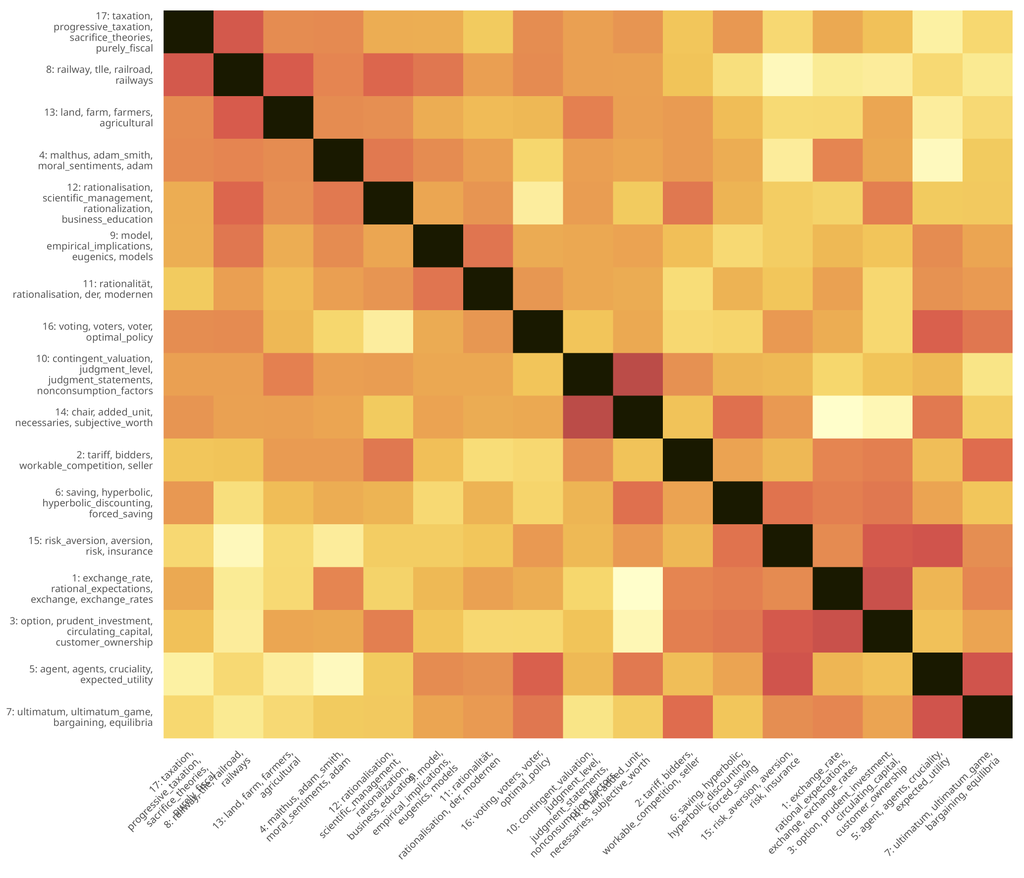

```r
backbone_names <- sentences %>%
  distinct(backbone_community, label_backbone_community)

mat_sim_ordered <- sim_mat[ordered_idx, ordered_idx]
communities_ordered <- backbone_centroids$backbone_community[ordered_idx]
rownames(mat_sim_ordered) <- colnames(mat_sim_ordered) <- communities_ordered

# create wrapped character labels and substitute into matrix names
wrapped_map <- backbone_names$label_backbone_community
names(wrapped_map) <- backbone_names$backbone_community
wrapped_map <- stringr::str_wrap(wrapped_map, 30)

rownames(mat_sim_ordered) <- wrapped_map[rownames(mat_sim_ordered)]
colnames(mat_sim_ordered) <- wrapped_map[colnames(mat_sim_ordered)]

# prepare long table for ggplot
sim_df <- as.data.frame(mat_sim_ordered)
sim_df$Var1 <- rownames(sim_df)
sim_long <- reshape2::melt(
  sim_df,
  id.vars = "Var1",
  variable.name = "Var2",
  value.name = "similarity"
)
sim_long$Var1 <- factor(sim_long$Var1, levels = rev(rownames(mat_sim_ordered)))
sim_long$Var2 <- factor(sim_long$Var2, levels = colnames(mat_sim_ordered))

# heatmap plot (returned as object) with wrapped labels on axes
heatmap_plot <- ggplot(sim_long, aes(x = Var2, y = Var1, fill = similarity)) +
  geom_raster(show.legend = FALSE) +
  scale_fill_scico(palette = "lajolla", direction = -1) +
  theme_minimal(base_size = 12) +
  theme(
    axis.text.x = element_text(angle = 45, hjust = 1),
    axis.title = element_blank(),
    panel.grid = element_blank()
  )

ggsave(
  here("pictures", "backbone_communities_heatmap.png"),
  heatmap_plot,
  units = "cm",
  width = 35,
  height = 30,
  dpi = 300
)

knitr::include_graphics(here("pictures", "backbone_communities_heatmap.png"))
```

```r
rm(backbone_centroids, backbone_centroid_matrix, mat_scaled, d, hc)
```

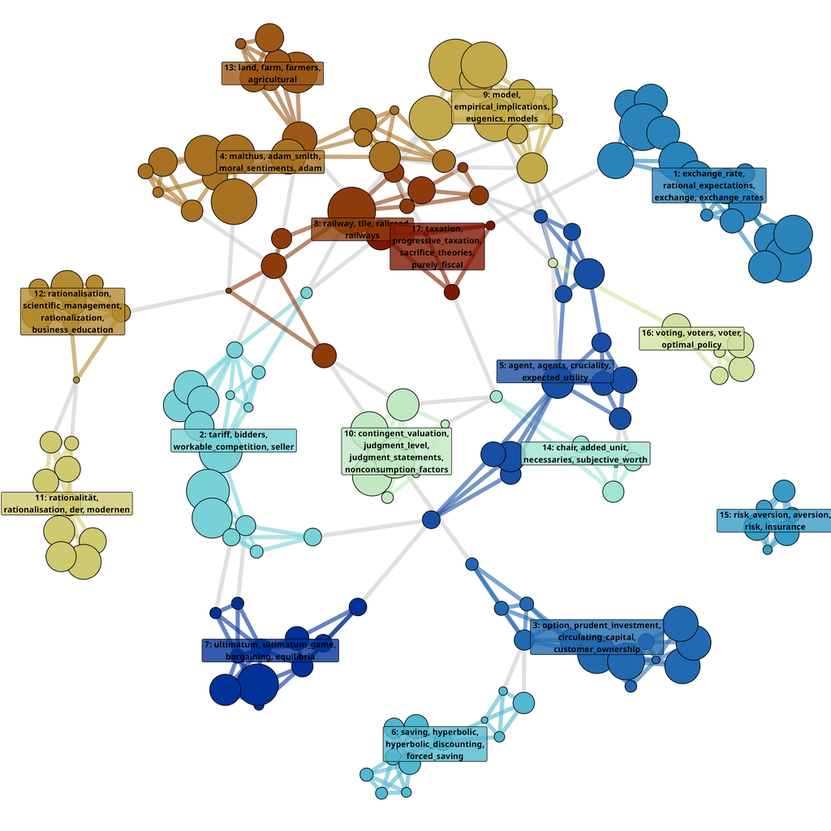

```r
sentences[, size_window := .N, by = window]
sentences[,
  proportion_hdbscan_cluster := .N / size_window,
  by = .(HDBSCAN_cluster, window)
]
backbone_network <- backbone_network %>%
  activate("nodes") %>%
  left_join(
    sentences %>%
      distinct(
        cluster_id,
        HDBSCAN_cluster,
        backbone_community,
        label_hdbscan_cluster,
        label_backbone_community,
        proportion_hdbscan_cluster
      ),
    by = "cluster_id"
  )

backbone_network <- backbone_network %>%
  activate("edges") %>%
  mutate(
    community_from = .N()[["community"]][from],
    community_to = .N()[["community"]][to],
    edge_community = if_else(
      community_from == community_to,
      community_from,
      NA_character_
    ),
    edge_community = factor(edge_community, levels = comm_levels)
  )

# compute layout and community centroids
set.seed(89)
layout <- ggraph::create_layout(backbone_network, layout = "fr")

community_average <- layout %>%
  as_tibble() %>%
  group_by(community) %>%
  summarize(
    x = mean(x, na.rm = TRUE),
    y = mean(y, na.rm = TRUE),
    .groups = "drop"
  ) %>%
  left_join(
    layout %>% as_tibble() %>% distinct(community, label_backbone_community),
    by = "community"
  )

# plot: edges coloured by edge_community when endpoints share same community, otherwise grey
backbone_network_plot <- ggraph(layout) +
  geom_edge_link(
    aes(colour = edge_community),
    alpha = 0.6,
    width = 2,
    show.legend = FALSE
  ) +
  geom_node_point(
    aes(fill = community, size = proportion_hdbscan_cluster),
    show.legend = FALSE,
    shape = 21
  ) +
  geom_label(
    data = community_average,
    aes(
      x = x,
      y = y,
      label = str_wrap(label_backbone_community, 30),
      fill = community
    ),
    size = 3,
    fontface = "bold",
    alpha = 0.8,
    show.legend = FALSE
  ) +
  scale_edge_width(range = c(0.2, 3)) +
  scale_size_continuous(range = c(1, 25)) +
  labs(edge_width = "Avg similarity") +
  scale_edge_color_manual(values = cluster_colors, na.value = "grey80") +
  scale_fill_manual(values = cluster_colors) +
  theme_void()

ggsave(
  here("pictures", "backbone_communities_network.png"),
  backbone_network_plot,
  units = "cm",
  width = 30,
  height = 30,
  dpi = 300
)

knitr::include_graphics(here("pictures", "backbone_communities_network.png"))
```

```r
set.seed(89)
backbone_network_ggiraph_plot <- ggraph(layout) +
  geom_edge_link(
    aes(colour = edge_community),
    alpha = 0.6,
    width = 2,
    show.legend = FALSE
  ) +
  # interactive node points: tooltip = label_hdbscan_cluster, data_id = cluster_id
  geom_point_interactive(
    aes(
      x = x,
      y = y,
      fill = community,
      size = proportion_hdbscan_cluster,
      tooltip = str_c(
        label_hdbscan_cluster,
        "\nPeriod:",
        window,
        "\nProportion of sentences in window: ",
        round(proportion_hdbscan_cluster * 100, 2),
        "%"
      ),
      data_id = cluster_id
    ),
    show.legend = FALSE,
    shape = 21
  ) +
  scale_size_continuous(range = c(1, 20)) +
  labs(edge_width = "Avg similarity") +
  scale_edge_color_manual(values = cluster_colors, na.value = "grey80") +
  scale_fill_manual(values = cluster_colors) +
  theme_void()

# create interactive girafe object with sensible hover/tooltip styling
girafe_obj <- ggiraph::girafe(
  ggobj = backbone_network_ggiraph_plot,
  width_svg = 16,
  height_svg = 10,
  options = list(
    ggiraph::opts_selection(type = "single"),
    ggiraph::opts_zoom(min = 1, max = 12), # wheel to zoom, drag to pan
    ggiraph::opts_toolbar(position = "topright")
  )
)

girafe_obj
```

[interactive chart not shown]

The next visualisation takes the same nodes and edges but repositions the nodes in a temporal layout, with time on the x-axis and communities stacked on the y-axis. It allows to see how backbone communities evolve over time.

```r
# per-window equally spaced y to avoid overlap
nodes_pos <- backbone_network %>%
    activate("nodes") %>%
    as_tibble(.name_repair = "minimal") |>
    mutate(x = as.integer(factor(window, levels = window_levels))) |>
  group_by(window) %>%
  arrange(desc(community), .by_group = TRUE) %>%
  mutate(
    n_in_window = n(),
    y = ifelse(n_in_window == 1, 0, seq(-1, 1, length.out = n_in_window))
  ) %>%
  ungroup()

# distribute nodes vertically within each (community, window) cell to avoid overlap
# compute per-(community,x) offsets without calling seq() on a vector
# compute required band per community (max nodes in any x for that community)
comm_band <- nodes_pos %>%
  mutate(community = factor(community, levels = comm_levels)) %>%
  group_by(community, x) %>%
  summarise(n_in_cell = n(), .groups = "drop") %>%
  group_by(community) %>%
  summarise(
    max_in_column = max(n_in_cell, na.rm = TRUE),
    .groups = "drop"
  ) %>%
  arrange(community) %>%
  mutate(
    max_in_column = pmax(max_in_column, 1L),
    pad = 0.7, # vertical padding between community bands
    band = max_in_column + pad # total vertical band height for the community
  ) %>%
  mutate(
    baseline = cumsum(lag(band, default = 0)) + band / 2 # center y for each community band
  ) %>%
  select(community, band, baseline)

# assign nodes within their community/x band
nodes_pos <- nodes_pos %>%
  mutate(community = factor(community, levels = comm_levels)) %>%
  left_join(comm_band, by = "community") %>%
  group_by(community, x) %>%
  arrange(window, cluster_id, .by_group = TRUE) %>%
  mutate(
    n_in_cell = n(),
    # centered offsets inside the community band; works for n_in_cell == 1 as well
    offset = (row_number() - 0.5) * band / n_in_cell - band / 2,
    y = baseline + offset
  ) %>%
  ungroup() %>%
  select(cluster_id, x, y, community)

# join positions into the graph nodes (match keys exactly)
temporal_backbone_network <- backbone_network %>%
  activate("nodes") %>%
  left_join(nodes_pos, by = c("cluster_id", "community"))

# compute label positions for communities (uses comm_band and layout from above)
community_label_positions <- comm_band %>%
  left_join(
    layout %>% as_tibble() %>% distinct(community, label_backbone_community),
    by = "community"
  ) %>%
  arrange(match(community, comm_levels)) %>%
  mutate(label = str_wrap(label_backbone_community, 40))

temporal_network_plot <- ggraph(
  temporal_backbone_network,
  layout = "manual",
  x = x,
  y = y
) +
  geom_edge_link(
    aes(colour = edge_community),
    alpha = 0.5,
    show.legend = FALSE,
    width = 2
  ) +
  geom_label(
    aes(
      x = x,
      y = y,
      label = cluster_id,
      fill = community,
      size = proportion_hdbscan_cluster
    ),
    label.padding = unit(0.12, "lines"),
    show.legend = FALSE,
    alpha = 0.9
  ) +
  scale_fill_manual(values = cluster_colors) +
  scale_edge_color_manual(values = cluster_colors, na.value = "grey80") +
  scale_x_continuous(
    breaks = seq_along(window_levels),
    labels = window_levels
  ) +
  # y axis showing community labels at their baseline positions
  scale_y_continuous(
    breaks = community_label_positions$baseline,
    labels = community_label_positions$label,
    expand = expansion(add = c(1, 0.8))
  ) +
  scale_size_continuous(range = c(3, 10)) +
  labs(x = NULL, y = NULL) +
  theme_minimal() +
  theme(
    panel.grid = element_blank(),
    axis.title.y = element_blank(),
    axis.text.y = element_text(size = 8, hjust = 1),
    axis.ticks.y = element_line(color = "grey50"),
    axis.line.y = element_line(color = "grey50"),
    axis.line.x = element_line(color = "grey50"),
    axis.ticks.x = element_line(color = "grey50"),
    axis.text.x = element_text(angle = 45, hjust = 1, vjust = 1, size = 9)
  )

ggsave(
  here("pictures", "temporal_network_plot.png"),
  temporal_network_plot,
  units = "cm",
  width = 30,
  height = 30,
  dpi = 300
)
```

```r
temporal_network_ggiraph_plot <- ggraph(
  temporal_backbone_network,
  layout = "manual",
  x = x,
  y = y
) +
  geom_edge_link(
    aes(colour = edge_community),
    alpha = 0.5,
    show.legend = FALSE
  ) +
  geom_point_interactive(
    aes(
      x = x,
      y = y,
      fill = community,
      size = proportion_hdbscan_cluster,
      tooltip = str_c(
        label_hdbscan_cluster,
        "\nPeriod:",
        window,
        "\nProportion of sentences in window: ",
        round(proportion_hdbscan_cluster * 100, 2),
        "%"
      ),
      data_id = cluster_id
    ),
    show.legend = FALSE,
    shape = 21,
    alpha = 0.9
  ) +
  scale_fill_manual(values = cluster_colors) +
  scale_edge_color_manual(values = cluster_colors, na.value = "grey80") +
  scale_x_continuous(
    breaks = seq_along(window_levels),
    labels = window_levels
  ) +
  # y axis showing community labels at their baseline positions
  scale_y_continuous(
    breaks = community_label_positions$baseline,
    labels = community_label_positions$label,
    expand = expansion(add = c(0.9, 0.9))
  ) +
  scale_size_continuous(range = c(2, 15)) +
  labs(x = NULL, y = NULL) +
  theme_minimal() +
  theme(
    panel.grid = element_blank(),
    axis.title.y = element_blank(),
    axis.text.y = element_text(size = 10, hjust = 1),
    axis.ticks.y = element_line(color = "grey50"),
    axis.line.y = element_line(color = "grey50"),
    axis.line.x = element_line(color = "grey50"),
    axis.ticks.x = element_line(color = "grey50"),
    axis.text.x = element_text(angle = 45, hjust = 1, vjust = 1, size = 9)
  )

# create interactive girafe object with sensible hover/tooltip styling
girafe_obj_time <- ggiraph::girafe(
  ggobj = temporal_network_ggiraph_plot,
  width_svg = 16,
  height_svg = 10,
  options = list(
    ggiraph::opts_selection(type = "single"),
    opts_tooltip(use_fill = TRUE),
    ggiraph::opts_zoom(min = 1, max = 12), # wheel to zoom, drag to pan
    ggiraph::opts_toolbar(position = "topright")
  )
)

girafe_obj_time
```

[interactive chart not shown]

## Description of the clusters: a reader’s guide

A series of indicators are produced for each clusters. Here are some explanations on how to read them.

### Header summary

**Note**

**What this shows**: size, time span, and main sources of the cluster.  
**How to read**:  
- **Sentences and share**: number of sentences in this cluster and its share of all analysed sentences.  
- **Period**: first and last window where this cluster appears.  
- **Recurring authors/journals**: most frequent contributors by sentence count.  
**Notes**: counts are sentence-level. Long papers can contribute many sentences.

### Top TF-IDF terms describing the community

**Tip**

**What this shows**: words or two-word phrases most specific to this intertemporal backbone community over the full period, in comparison to all other backbone communities.  
**How to read**: higher TF-IDF = greater within-cluster distinctiveness. Compare terms within this table.  
**Use**: quick topic fingerprint.  
**Caution**: This is not an “absolute” TF-IDF: to take into account the fact that more recent periods have more sentences, we average TF-IDF calculated at the window level.

### Top TF-IDF terms by hdbscan cluster

**Tip**

**What this shows**: the hdbscan cluster’s distinctive vocabulary.  
**How to read**: compare hdbscan clusters within the same backbone community to see terms that appear or fade.  
**Use**: detect shifts in focus, methods, or cases across time, as well as diversity within a backbone community.

### Distribution of sentences over time

**Note**

**What this shows**: yearly counts of sentences in this cluster.  
**How to read**: bars = activity level. Peaks = years with more writing on this theme.  
**Caution**: absolute counts, not shares. Later years may have more total publishing.

### Closest sentences from “rationality” and “rational” embeddings within the backbone community

**Note**

**What this shows**: sentences that have the highest cosine similarity with the “rational”/“rationality” embeddings  
**How to read**: examples of how this community talks about the future.  
**Caution**: ranked by the proximity with “rational”/“rationality” embeddings, not by the proximity with the centroid of the cluster (i.e. the average point in the cluster).

### Closest sentences to the backbone community centroid

**Note**

### Closest sentences to the hdbscan cluster centroids

**Tip**

### Top articles (most sentences) of the backbone community

**Note**

**What this shows**: works contributing the most sentences to this cluster.  
**Columns**: **Number sentences** and **Work Similarity**.  
— **Number sentences**: volume contributed by the work.  
— **Word Similarity**: mean of the cosine similarity to “rationality”/“rational” for that work’s sentences in this cluster.  
**How to read**: Most representative articles of the cluster. Worth clicking on the link to see more about what the article is about. Often a good way to understand how it talks about rationality.

### Top articles (most sentences) of each hdbscan cluster

**Note**

**What this shows**: same as above, but split by hdbscan cluster.  
**How to read**: see which articles contribute to which hdbscan clusters within the backbone community

### Most cited references in the backbone community

**Note**

**What this shows**: the references most often cited by the articles that contribute sentences to this community.

**Columns**  
- **First Author / Year / Journal**: metadata from the reference list.  
- **Citation by article**: number of *distinct articles in this cluster* that cite the reference.  
- **Citation by sentence**: **Citation by article** weighted by how many sentences those citing articles contribute to the cluster (higher = the reference is cited by more central articles in this cluster).

**How to read**: prefer **Citation by sentence** to identify anchors of the cluster; use **Citation by article** to see breadth of citing articles.

**Caveats**  
- The second table lists references *without stable IDs*. This helps recovering books but may be inaccurate.  
- Weighting captures cluster centrality of the *citing articles*, not the number of in-text mentions.  
- Abbreviated journal names may vary.

### Most cited references in each hdbscan clusters

**Tip**

**What this shows**: decade-level leaders by the same two indicators. **How to read**: compare decades and clusters in same decate to see which references anchor the community at different times.

### Column legend

- **Sentence**: quoted sentence.
- **Title**: clickable article title.
- **Year**: publication year.
- **Journal**: outlet.
- **Authors**: as listed.
- **Words Similarity**: cosine similarity to the embeddings of “rational”/“rationality”.
- **Centroid Similarity**: cosine similarity to the cluster’s centroid.
- **Distance to centroid**: distance to the hdbscan cluster’s centroid.
- **Number sentences**: sentences from that work in this cluster.

### General cautions

- Similarity values lie in [0,1]. Near-top differences can still matter.
- TF-IDF is comparative within this dataset.
- All counts reflect the top-1% sentences set used here.

# Description of the Clusters

```r
for (cluster in list_clusters) {
  cluster_data <- sentences %>%
    arrange(window) |>
    filter(backbone_community == !!cluster) %>%
    mutate(title = glue("<a href='{url}' target='_blank'>{title}</a>"))

  cluster_name <- cluster_data %>%
    pull(label_backbone_community) %>%
    unique

  hdbscan_clusters <- cluster_data %>%
    distinct(HDBSCAN_cluster, window, cluster_id)

  # extracting the first year and last year of the community
  window <- c(
    first(unique(cluster_data$window)) %>% str_extract("^\\d{4}"),
    last(unique(cluster_data$window)) %>% str_extract("\\d{4}$")
  )

  ################ Beginning of the template ######################
  cat(sprintf("  \n## Intertemporal cluster _%s_ \n\n", cluster_name))

  ############# General Info ##################
  cat(paste0(
    "  \nThe cluster gathers ",
    nrow(distinct(cluster_data, sentence_id, id)),
    " sentences from our corpus. It represents ",
    round(
      nrow(distinct(cluster_data, id, sentence_id)) /
        nrow(distinct(sentences, id, sentence_id)) *
        100,
      2
    ),
    "% of all the sentences selected over the whole period.\n"
  ))

  cat(paste0(
    "\nThe community exists from ",
    window[1],
    " to ",
    window[2],
    ". \n\n"
  ))

  recurring_journals <- cluster_data %>%
    select(journal, id) %>%
    add_count(journal, name = "nb_sentences") %>%
    distinct(journal, id, nb_sentences) %>%
    add_count(journal, name = "nb_articles") %>%
    distinct(journal, nb_sentences, nb_articles) %>%
    slice_max(order_by = nb_sentences, n = 6)
  cat(paste0(
    "The most recurring journals are ",
    paste0(
      recurring_journals$journal,
      " (",
      recurring_journals$nb_sentences,
      " sentences; ",
      recurring_journals$nb_articles,
      " articles)",
      collapse = ", "
    ),
    ".\n\n"
  ))

  if (hdbscan_clusters %>% nrow() > 1) {
    for (hdbscan_id in hdbscan_clusters$cluster_id) {
      authors <- recurring_authors[
        HDBSCAN_cluster ==
          hdbscan_clusters[cluster_id == hdbscan_id, ]$HDBSCAN_cluster &
          window == hdbscan_clusters[cluster_id == hdbscan_id, ]$window,
      ]

      cat(paste0(
        "\n- The most recurring authors of the cluster ",
        cluster_data[cluster_id == hdbscan_id, ]$label_hdbscan_cluster |>
          unique(),
        " (",
        hdbscan_clusters[cluster_id == hdbscan_id, ]$window,
        "): ",
        paste0(
          authors$authors,
          " (",
          authors$nb_sentences,
          " sentences; ",
          authors$nb_articles,
          " articles)",
          collapse = ", "
        ),
        ".\n\n"
      ))
    }
  }

  ############# TF-IDF ##################
  cat("\n### Top TF-IDF terms describing the community\n\n")
  # Extracting top terms in general and for window
  top_terms_cluster %>%
    filter(backbone_community == !!cluster) %>%
    select(token, mean_tf_idf) %>%
    kbl(col.names = c("Token", "TF-IDF")) %>%
    kable_styling(
      bootstrap_options = c("striped", "condensed"),
      font_size = 15
    ) %>%
    print()

  if (nrow(hdbscan_clusters) > 1) {
    cat(
      "\n### Top TF-IDF terms describing the different k-means clusters\n\n"
    )

    for (hdbscan_id in hdbscan_clusters$cluster_id) {
      time_window <- hdbscan_clusters %>%
        filter(cluster_id == hdbscan_id) %>%
        pull(window)

      hdbscan <- hdbscan_clusters %>%
        filter(cluster_id == hdbscan_id) %>%
        pull(HDBSCAN_cluster)

      cat(
        glue(
          "\n#### Top terms {cluster_data[cluster_id == hdbscan_id,]$label_hdbscan_cluster |> unique()} ({time_window})\n\n"
        )
      )

      top_terms_hdbscan_cluster %>%
        filter(window == time_window, HDBSCAN_cluster == hdbscan) %>%
        select(token, tf_idf) %>%
        kbl(col.names = c("Token", "TF-IDF")) %>%
        kable_styling(
          bootstrap_options = c("striped", "condensed"),
          font_size = 11
        ) %>%
        print()
    }

    # build a wide table of top-10 tokens per HDBSCAN cluster (columns = label_hdbscan_cluster)
    # top_terms_wide <- top_terms_hdbscan_cluster %>%
    #   filter(backbone_community == !!cluster) %>%
    #   arrange(window, HDBSCAN_cluster, desc(tf_idf)) %>%
    #   group_by(HDBSCAN_cluster, window) %>%
    #   slice_head(n = 10) %>%
    #   ungroup() %>%
    #   # attach human-readable hdbscan labels
    #   left_join(
    #     cluster_data %>%
    #       distinct(HDBSCAN_cluster, window, label_hdbscan_cluster),
    #     by = c("HDBSCAN_cluster", "window")
    #   ) %>%
    #   # rank tokens within each labelled cluster and pivot to wide
    #   group_by(label_hdbscan_cluster) %>%
    #   arrange(window, HDBSCAN_cluster, desc(tf_idf)) %>%
    #   mutate(rank = row_number()) %>%
    #   ungroup() %>%
    #   select(label_hdbscan_cluster, rank, token) %>%
    #   tidyr::pivot_wider(
    #     names_from = label_hdbscan_cluster,
    #     values_from = token
    #   ) %>%
    #   arrange(rank) %>%
    #   select(-rank)

    # # print as a single table: columns = HDBSCAN cluster labels, rows = top tokens
    # top_terms_wide %>%
    #   kbl(escape = FALSE, col.names = names(top_terms_wide)) %>%
    #   kable_styling(
    #     bootstrap_options = c("striped", "condensed"),
    #     font_size = 11
    #   ) %>%
    #   print()
  }

  ############# Distribution sentences ##################
  cat("\n### Distribution of sentences over time \n\n")

  plot(
    cluster_data %>%
      count(year) %>%
      ggplot(aes(x = year, y = n)) +
      geom_bar(stat = "identity") +
      scale_x_continuous(expand = c(0.01, 0), n.breaks = 10) +
      scale_y_continuous(expand = c(0.01, 0)) +
      theme_light(base_size = 20) +
      labs(y = "Number of sentences", x = NULL, title = NULL)
  )

  ####### Top Sentences ###################
  top_sentences_rationality_filtered <- top_sentences_rationality %>%
    filter(backbone_community == !!cluster) %>%
    left_join(distinct(
      cluster_data,
      title,
      journal,
      authors,
      url,
      sentence_id,
      id
    )) %>%
    mutate(title = glue("<a href='{url}' target='_blank'>{title}</a>"))
```

```r
  top_sentences_hdbscan_cluster_centroid_filtered <- top_sentences_hdbscan_cluster_centroid %>%
    filter(backbone_community == !!cluster) %>%
    left_join(
      distinct(
        cluster_data,
        title,
        year,
        journal,
        authors,
        id,
        sentence_id,
        url
      ),
      by = c("sentence_id", "id")
    ) %>%
    mutate(title = glue("<a href='{url}' target='_blank'>{title}</a>"))

  top_sentences_backbone_community_centroid_filtered <- top_sentences_backbone_community_centroid %>%
    filter(backbone_community == !!cluster) %>%
    left_join(
      distinct(
        cluster_data,
        title,
        year,
        journal,
        authors,
        id,
        sentence_id,
        url
      ),
      by = c("sentence_id", "id")
    ) %>%
    mutate(title = glue("<a href='{url}' target='_blank'>{title}</a>"))

  ############# Top sentences rationality ##################
  cat("\n\n")
  cat(
    "\n### Closest sentence from 'rational' and 'rationality' of the backbone community\n\n"
  )

  top_sentences_rationality_filtered %>%
    slice_max(similarity, n = 20, by = backbone_community) %>%
    select(
      sentence,
      title,
      year,
      journal,
      authors,
      similarity
    ) %>%
    kbl(
      escape = FALSE,
      col.names = c(
        "Sentence",
        "Title",
        "Year",
        "Journal",
        "Authors",
        "Words Similarity"
      )
    ) %>%
    kable_styling(
      bootstrap_options = c("striped", "condensed"),
      font_size = 12
    ) %>%
    column_spec(2, "3.5cm") %>%
    print()

  if (nrow(hdbscan_clusters) > 1) {
    cat(
      "\n### Closest sentences from 'rational' and 'rationality' of the HDBSCAN cluster\n\n"
    )

    for (hdbscan_id in unique(cluster_data$cluster_id)) {
      time_window <- hdbscan_clusters %>%
        filter(cluster_id == hdbscan_id) %>%
        pull(window)

      hdbscan <- hdbscan_clusters %>%
        filter(cluster_id == hdbscan_id) %>%
        pull(HDBSCAN_cluster)

      cat(
        glue(
          "\n#### Closes sentences {cluster_data[cluster_id == hdbscan_id,]$label_hdbscan_cluster |> unique()} ({time_window})\n\n"
        )
      )

      top_sentences_rationality_filtered %>%
        filter(window == time_window, HDBSCAN_cluster == hdbscan) %>%
        slice_max(similarity, n = 10) %>%
        select(
          sentence,
          title,
          year,
          journal,
          authors,
          similarity
        ) %>%
        kbl(
          escape = FALSE,
          col.names = c(
            "Sentence",
            "Title",
            "Year",
            "Journal",
            "Authors",
            "Words Similarity"
          )
        ) %>%
        kable_styling(
          bootstrap_options = c("striped", "condensed"),
          font_size = 12
        ) %>%
        column_spec(2, "3.5cm") %>%
        print()
    }
  }

  ############# Top sentences centroid ##################
  cat("\n### Closest sentences of the backbone community's centroid\n\n")

  top_sentences_backbone_community_centroid_filtered %>%
    slice_max(similarity_backbone_centroid, n = 15) %>%
    select(
      sentence,
      title,
      year,
      journal,
      authors,
      similarity_backbone_centroid
    ) %>%
    kbl(
      escape = FALSE,
      col.names = c(
        "Sentence",
        "Title",
        "Year",
        "Journal",
        "Authors",
        "Similarity to Backbone Centroid"
      )
    ) %>%
    kable_styling(
      bootstrap_options = c("striped", "condensed"),
      font_size = 13
    ) %>%
    column_spec(2, "3.5cm") %>%
    print()

  if (nrow(hdbscan_clusters) > 1) {
    cat(
      "\n### Closest sentences of each HDBSCAN cluster's centroid composing the backbone community\n\n"
    )

    for (hdbscan_id in unique(cluster_data$cluster_id)) {
      time_window <- hdbscan_clusters %>%
        filter(cluster_id == hdbscan_id) %>%
        pull(window)

      hdbscan <- hdbscan_clusters %>%
        filter(cluster_id == hdbscan_id) %>%
        pull(HDBSCAN_cluster)

      cat(
        glue(
          "\n#### Closes sentences {cluster_data[cluster_id == hdbscan_id,]$label_hdbscan_cluster |> unique()} ({time_window})\n\n"
        )
      )

      top_sentences_hdbscan_cluster_centroid_filtered %>%
        filter(window == time_window, HDBSCAN_cluster == hdbscan) %>%
        slice_max(similarity_hdbscan_centroid, n = 10) %>%
        select(
          sentence,
          title,
          year,
          journal,
          authors,
          similarity_hdbscan_centroid
        ) %>%
        kbl(
          escape = FALSE,
          col.names = c(
            "Sentence",
            "Title",
            "Year",
            "Journal",
            "Authors",
            "Similarity to HDSBSCAN Centroid"
          )
        ) %>%
        kable_styling(
          bootstrap_options = c("striped", "condensed"),
          font_size = 12
        ) %>%
        column_spec(2, "3.5cm") %>%
        print()
    }
  }

  ############# Top articles ##################
  cat("\n### Top articles (most sentences) of the backbone cluster\n\n")
  # Extracting top terms in general and for window
  cluster_data |>
    mutate(
      mean_similarity = mean(similarity_rv) %>% round(3),
      n = n(),
      weighted_n = if_else(!is.na(n_sentences), n() / n_sentences, NA_real_),
      .by = id
    ) %>%
    distinct(
      title,
      year,
      journal,
      authors,
      n,
      weighted_n,
      mean_similarity
    ) |>
    slice_max(n, n = 15, with_ties = FALSE) %>%
    kbl(
      escape = FALSE,
      col.names = c(
        "Title",
        "Year",
        "Journal",
        "Authors",
        "Number sentences",
        "Proportion sentences",
        "Words Similarity"
      )
    ) %>%
    kable_styling(
      bootstrap_options = c("striped", "condensed"),
      font_size = 13
    ) %>%
    print()

  if (nrow(hdbscan_clusters) > 1) {
    cat(
      "\n### Top articles (most sentences) of the cluster for each time window{.panel-tabset}\n\n"
    )
```

```r
    for (hdbscan_id in unique(cluster_data$cluster_id)) {
      time_window <- hdbscan_clusters %>%
        filter(cluster_id == hdbscan_id) %>%
        pull(window)

      hdbscan <- hdbscan_clusters %>%
        filter(cluster_id == hdbscan_id) %>%
        pull(HDBSCAN_cluster)

      cat(
        glue(
          "\n#### Top articles for {cluster_data[cluster_id == hdbscan_id,]$label_hdbscan_cluster |> unique()} ({time_window})\n\n"
        )
      )

      cluster_data %>%
        filter(window == time_window, HDBSCAN_cluster == hdbscan) %>%
        mutate(
          mean_similarity = mean(similarity_rv) %>% round(3),
          n = n(),
          weighted_n = if_else(
            !is.na(n_sentences),
            n() / n_sentences,
            NA_real_
          ),
          .by = id
        ) %>%
        distinct(
          title,
          year,
          journal,
          authors,
          n,
          weighted_n,
          mean_similarity
        ) %>%
        slice_max(n, n = 10, with_ties = FALSE) %>%
        kbl(
          escape = FALSE,
          col.names = c(
            "Title",
            "Year",
            "Journal",
            "Authors",
            "Number sentences",
            "Proportion sentences",
            "Words Similarity"
          )
        ) %>%
        kable_styling(
          bootstrap_options = c("striped", "condensed"),
          font_size = 13
        ) %>%
        print()
    }
  }

  ############## Top References ##################
  cat("\n### Most cited references in the backbone community\n\n")

  top_refs %>%
    filter(backbone_community == cluster) %>%
    distinct(Nom, Annee, Revue_Abbrege, absolute_cit, weighted_cit) %>%
    filter(absolute_cit > 1) |>
    slice_max(absolute_cit, n = 15, with_ties = FALSE) %>%
    kbl(
      escape = FALSE,
      col.names = c(
        "First Author",
        "Year",
        "Journal",
        "Citation by article",
        "Citation by sentence"
      )
    ) %>%
    kable_styling(
      bootstrap_options = c("striped", "condensed"),
      font_size = 12
    ) %>%
    print()

  top_refs_without_id %>%
    filter(backbone_community == cluster) %>%
    distinct(Nom, Annee, Revue_Abbrege, absolute_cit, weighted_cit) %>%
    filter(absolute_cit > 1) |>
    slice_max(absolute_cit, n = 15, with_ties = FALSE) %>%
    kbl(
      escape = FALSE,
      col.names = c(
        "First Author",
        "Year",
        "Journal",
        "Citation by article",
        "Citation by sentence"
      )
    ) %>%
    kable_styling(
      bootstrap_options = c("striped", "condensed"),
      font_size = 12
    ) %>%
    print()

  if (nrow(hdbscan_clusters) > 1) {
    cat("\n### Most cited references per hdbscan clusters\n\n")

    for (hdbscan_id in unique(cluster_data$cluster_id)) {
      time_window <- hdbscan_clusters %>%
        filter(cluster_id == hdbscan_id) %>%
        pull(window)

      hdbscan <- hdbscan_clusters %>%
        filter(cluster_id == hdbscan_id) %>%
        pull(HDBSCAN_cluster)

      top_ref_cluster <- top_refs %>%
        filter(window == time_window, HDBSCAN_cluster == hdbscan) %>%
        distinct(
          Nom,
          Annee,
          Revue_Abbrege,
          absolute_cluster_cit,
          weighted_cluster_cit
        ) %>%
        slice_max(absolute_cluster_cit, n = 10, with_ties = FALSE)

      top_ref_without_id_cluster <- top_refs_without_id %>%
        filter(window == time_window, HDBSCAN_cluster == hdbscan) %>%
        distinct(
          Nom,
          Annee,
          Revue_Abbrege,
          absolute_cluster_cit,
          weighted_cluster_cit
        ) %>%
        slice_max(absolute_cluster_cit, n = 10, with_ties = FALSE)

      if (nrow(top_ref_cluster) != 0 | nrow(top_ref_without_id_cluster) != 0) {
        cat(
          glue(
            "\n#### Most cited references for {cluster_data[cluster_id == hdbscan_id,]$label_hdbscan_cluster |> unique()} ({time_window})\n\n"
          )
        )
        if (nrow(top_ref_cluster) > 0) {
          top_ref_cluster %>%
            kbl(
              escape = FALSE,
              col.names = c(
                "First Author",
                "Year",
                "Journal",
                "Citation by article",
                "Citation by sentence"
              )
            ) %>%
            kable_styling(
              bootstrap_options = c("striped", "condensed"),
              font_size = 12
            ) %>%
            print()
        }

        if (nrow(top_ref_without_id_cluster) > 0) {
          top_ref_without_id_cluster %>%
            kbl(
              escape = FALSE,
              col.names = c(
                "First Author",
                "Year",
                "Journal",
                "Citation by article",
                "Citation by sentence"
              )
            ) %>%
            kable_styling(
              bootstrap_options = c("striped", "condensed"),
              font_size = 12
            ) %>%
            print()
        }
      }
    }
  }
}
```

## Intertemporal cluster *1: exchange_rate, rational_expectations, exchange, exchange_rates*

The cluster gathers 44808 sentences from our corpus. It represents 17.61% of all the sentences selected over the whole period.

The community exists from 1900 to 2009.

The most recurring journals are Journal of Monetary Economics (2802 sentences; 730 articles), Journal of Economic Dynamics and Control (2508 sentences; 518 articles), The American Economic Review (2211 sentences; 964 articles), Journal of Money, Credit and Banking (1949 sentences; 738 articles), The Economic Journal (1535 sentences; 533 articles), Journal of Political Economy (1403 sentences; 540 articles).

- The most recurring authors of the cluster 1_0_1900-1919: gold, silver, quantity_theory, currency, money (1900-1919): Jacob H. Hollander (12 sentences; 3 articles), Wesley C. Mitchell (12 sentences; 4 articles), T. N. Carver (11 sentences; 2 articles), J. Laurence Laughlin (10 sentences; 7 articles), Charles A. Conant (10 sentences; 3 articles), A. C. Pigou (10 sentences; 3 articles).
- The most recurring authors of the cluster 1_0_1920-1929: gold, quantity_theory, currency, gold_standard, credit (1920-1929): Arthur F. Burns (10 sentences; 1 articles), Arthur W. Marget (10 sentences; 1 articles), Edwin Cannan (9 sentences; 4 articles), J. Laurence Laughlin (8 sentences; 2 articles), Harold L. Reed (6 sentences; 3 articles), Harold G. Moulton (6 sentences; 1 articles).
- The most recurring authors of the cluster 1_0_1930-1939: quantity_theory, gold, circulation, money, keynes (1930-1939): Kei Shibata (37 sentences; 5 articles), Arthur W. Marget (36 sentences; 6 articles), Jacob Viner (21 sentences; 4 articles), T. N. Carver (18 sentences; 2 articles), David Davidson (14 sentences; 1 articles), J. M. Keynes (13 sentences; 7 articles).
- The most recurring authors of the cluster 1_0_1940-1949: keynes, gold, money, quantity_theory, gold_standard (1940-1949): Frank D. Graham (29 sentences; 5 articles), M. Bronfenbrenner (14 sentences; 1 articles), J. Carl Poindexter (10 sentences; 3 articles), Walter S. Salant (10 sentences; 2 articles), Franco Modigliani (10 sentences; 1 articles), Clark Warburton (9 sentences; 7 articles).
- The most recurring authors of the cluster 1_1_1950-1959: quantity_theory, keynes, liquidity, money, monetary (1950-1959): Robert E. Kuenne (19 sentences; 4 articles), Don Patinkin (18 sentences; 6 articles), Clark Warburton (15 sentences; 5 articles), Milton Friedman (11 sentences; 5 articles), Walter A. Morton (9 sentences; 4 articles), James R. Schlesinger (8 sentences; 3 articles).
- The most recurring authors of the cluster 1_1_1960-1969: reserves, quantity_theory, money, liquidity, money_supply (1960-1969): Harry G. Johnson (48 sentences; 16 articles), Allan H. Meltzer (39 sentences; 9 articles), Karl Brunner (27 sentences; 8 articles), David Laidler (19 sentences; 5 articles), Paul Davidson (19 sentences; 7 articles), Walter P. Egle (19 sentences; 5 articles).
- The most recurring authors of the cluster 1_2_1970-1979: rational_expectations, expectations, expectations_hypothesis, forecasts, adaptive_expectations (1970-1979): Stephen J. Turnovsky (88 sentences; 16 articles), Shiller R. (80 sentences; 1 articles), Edmund S. Phelps (53 sentences; 7 articles), Thomas J. Sargent (43 sentences; 13 articles), John B. Taylor (34 sentences; 5 articles), Malcolm R. Gray (27 sentences; 2 articles).
- The most recurring authors of the cluster 1_3_1970-1979: monetary_policy, money_supply, monetary, money_stock, money (1970-1979): Friedman B. (33 sentences; 4 articles), William Poole (32 sentences; 10 articles), Harry G. Johnson (31 sentences; 12 articles), Paul Davidson (27 sentences; 4 articles), John Williamson (25 sentences; 5 articles), Stephen J. Turnovsky (23 sentences; 10 articles).
- The most recurring authors of the cluster 1_4_1970-1979: inflation, inflationary, inflation_rate, inflationary_expectations, expectations (1970-1979): Franco Modigliani (13 sentences; 3 articles), Edmund S. Phelps (12 sentences; 7 articles), Thomas J. Sargent (12 sentences; 6 articles), James E. Pesando (11 sentences; 5 articles), David Laidler (11 sentences; 4 articles), Stephen J. Turnovsky (10 sentences; 7 articles).
- The most recurring authors of the cluster 1_15_1980-1989: rational_expectations, expectations, expectations_equilibrium, expectations_models, expectations_hypothesis (1980-1989): Allen B. (50 sentences; 6 articles), Stephen J. Turnovsky (46 sentences; 15 articles), John J. Struthers (43 sentences; 1 articles), Roman Frydman (42 sentences; 4 articles), Margaret Bray (40 sentences; 2 articles), Randall Bausor (40 sentences; 4 articles).
- The most recurring authors of the cluster 1_18_1980-1989: inflation, monetary_policy, money_supply, monetary, expectations (1980-1989): Robert J. Barro (32 sentences; 7 articles), Bennett T. McCallum (29 sentences; 10 articles), William Fellner (28 sentences; 7 articles), Robert J. Gordon (28 sentences; 9 articles), Robert G. King (27 sentences; 3 articles), Christopher A. Sims (25 sentences; 7 articles).
- The most recurring authors of the cluster 1_8_1980-1989: exchange_rate, devaluation, exchange, exchange_rates, foreign_exchange (1980-1989): Jeffrey A. Frankel (41 sentences; 10 articles), Rudiger Dornbusch (32 sentences; 10 articles), Stephen J. Turnovsky (31 sentences; 12 articles), Jacob A. Frenkel (27 sentences; 12 articles), Richard Meese (20 sentences; 2 articles), Kent P. Kimbrough (19 sentences; 3 articles).
- The most recurring authors of the cluster 1_3_1990-1999: rational_expectations, expectations, expectations_equilibrium, forecasts, learning (1990-1999): David E. Runkle (66 sentences; 6 articles), Arlington W. Williams (59 sentences; 2 articles), Raymond C. Battalio (58 sentences; 2 articles), Gerald P. Dwyer (57 sentences; 1 articles), Timothy I. Mason (57 sentences; 1 articles), Mordecai Kurz (56 sentences; 5 articles).
- The most recurring authors of the cluster 1_2_1990-1999: inflation, monetary_policy, rational_expectations, expectations, monetary (1990-1999): Michael Woodford (46 sentences; 8 articles), Paul Davidson (36 sentences; 9 articles), Ben S. Bernanke (36 sentences; 8 articles), Mark P. Taylor (32 sentences; 13 articles), Sheila C. Dow (30 sentences; 5 articles), Jac J. Sijben (29 sentences; 1 articles).
- The most recurring authors of the cluster 1_3_2000-2009: monetary_policy, inflation, central_bank, rational_expectations, monetary (2000-2009): Michael Woodford (68 sentences; 15 articles), Preston B. (59 sentences; 2 articles), Bhattacharya J. (49 sentences; 7 articles), Maurizio Motolese (48 sentences; 3 articles), Berentsen A. (39 sentences; 5 articles), Dennis R. (38 sentences; 3 articles).
- The most recurring authors of the cluster 1_4_2000-2009: rational_expectations, expectations, expectations_equilibrium, agents, learning (2000-2009): Branch W. (117 sentences; 5 articles), Heinemann M. (66 sentences; 2 articles), Maik Heinemann (64 sentences; 2 articles), Evans G. (58 sentences; 7 articles), Brock W.A. (56 sentences; 5 articles), Preston B. (54 sentences; 2 articles).

### Top TF-IDF terms describing the community

| Token | TF-IDF |
| --- | --- |
| exchange_rate | 0.0487959 |
| rational_expectations | 0.0168922 |
| exchange | 0.0150349 |
| exchange_rates | 0.0136159 |
| expectations | 0.0128561 |
| inflation | 0.0127905 |
| foreign_exchange | 0.0101620 |
| inflationary | 0.0096548 |
| devaluation | 0.0087035 |
| silver | 0.0086644 |
| gold | 0.0080506 |
| exchange_market | 0.0080457 |
| inflation_rate | 0.0078042 |
| expectations_equilibrium | 0.0075890 |
| monetary_policy | 0.0072289 |
| inflationary_expectations | 0.0072083 |
| anticipated_inflation | 0.0071150 |
| quantity_theory | 0.0065269 |
| money_supply | 0.0063750 |
| credit | 0.0061999 |

### Top TF-IDF terms describing the different k-means clusters

#### Top terms 1_0_1900-1919: gold, silver, quantity_theory, currency, money (1900-1919)

| Token | TF-IDF |
| --- | --- |
| gold | 0.0177955 |
| silver | 0.0086644 |
| quantity_theory | 0.0072736 |
| currency | 0.0061919 |
| money | 0.0047832 |
| metals | 0.0040884 |
| reserve_association | 0.0034324 |
| marginal_human | 0.0034324 |
| circulation | 0.0034199 |
| legal_tender | 0.0034070 |
| gold_supply | 0.0033426 |
| bondholders | 0.0032760 |
| purchasing_power | 0.0030779 |
| hoarded | 0.0030527 |
| quantitative_theory | 0.0029696 |

#### Top terms 1_0_1920-1929: gold, quantity_theory, currency, gold_standard, credit (1920-1929)

| Token | TF-IDF |
| --- | --- |
| gold | 0.0128911 |
| quantity_theory | 0.0103055 |
| currency | 0.0068256 |
| gold_standard | 0.0065118 |
| credit | 0.0061999 |
| quantity_theorists | 0.0054089 |
| money | 0.0045032 |
| stuff | 0.0043612 |
| dr_anderson’s | 0.0043512 |
| english_stuff | 0.0043512 |
| foreign_stuff | 0.0043512 |
| monetary_theory | 0.0038104 |
| banks | 0.0037659 |
| reserve | 0.0036011 |
| metaphysics | 0.0035495 |

#### Top terms 1_0_1930-1939: quantity_theory, gold, circulation, money, keynes (1930-1939)

| Token | TF-IDF |
| --- | --- |
| quantity_theory | 0.0075945 |
| gold | 0.0071789 |
| circulation | 0.0062543 |
| money | 0.0057774 |
| keynes | 0.0057022 |
| velocity | 0.0053937 |
| banking | 0.0036384 |
| monetary | 0.0032976 |
| gold_standard | 0.0031498 |
| velocities | 0.0028752 |
| liquidity | 0.0027317 |
| monetary_system | 0.0027221 |
| liquidity_preference | 0.0026524 |
| purchasing_power | 0.0026489 |
| neutral_money | 0.0026462 |

#### Top terms 1_0_1940-1949: keynes, gold, money, quantity_theory, gold_standard (1940-1949)

| Token | TF-IDF |
| --- | --- |
| keynes | 0.0067702 |
| gold | 0.0050866 |
| money | 0.0044733 |
| quantity_theory | 0.0044423 |
| gold_standard | 0.0042222 |
| monetary | 0.0040954 |
| keynes’s | 0.0030282 |
| keynesian | 0.0029734 |
| inflation | 0.0028519 |
| liquidity | 0.0027741 |
| monetary_management | 0.0025510 |
| bank | 0.0025205 |
| circulation | 0.0024658 |
| liquidity_preference | 0.0024445 |
| commodity_reserve | 0.0023352 |

#### Top terms 1_1_1950-1959: quantity_theory, keynes, liquidity, money, monetary (1950-1959)

| Token | TF-IDF |
| --- | --- |
| quantity_theory | 0.0054470 |
| keynes | 0.0043738 |
| liquidity | 0.0043538 |
| money | 0.0042537 |
| monetary | 0.0041714 |
| liquidity_preference | 0.0036331 |
| say’s | 0.0033287 |
| say’s_law | 0.0031355 |
| inflation | 0.0031084 |
| reserve | 0.0026997 |
| monetary_policy | 0.0023296 |
| banking | 0.0022782 |
| velocity | 0.0021952 |
| federal_reserve | 0.0021632 |
| gold | 0.0021352 |

#### Top terms 1_1_1960-1969: reserves, quantity_theory, money, liquidity, money_supply (1960-1969)

| Token | TF-IDF |
| --- | --- |
| reserves | 0.0052633 |
| quantity_theory | 0.0051690 |
| money | 0.0046509 |
| liquidity | 0.0044806 |
| money_supply | 0.0043384 |
| monetary | 0.0034222 |
| balances | 0.0032848 |
| gold | 0.0032165 |
| monetary_policy | 0.0030566 |
| reserve | 0.0029274 |
| deposits | 0.0028834 |
| liquidity_preference | 0.0027674 |
| bank | 0.0024731 |
| time_deposits | 0.0024474 |
| devaluation | 0.0022643 |

#### Top terms 1_2_1970-1979: rational_expectations, expectations, expectations_hypothesis, forecasts, adaptive_expectations (1970-1979)

| Token | TF-IDF |
| --- | --- |
| rational_expectations | 0.0230106 |
| expectations | 0.0216094 |
| expectations_hypothesis | 0.0050479 |
| forecasts | 0.0047454 |
| adaptive_expectations | 0.0045866 |
| adaptive | 0.0044642 |
| myopic_foresight | 0.0042502 |
| perfect_myopic | 0.0041110 |
| expectations_mechanism | 0.0040869 |
| forecast | 0.0038562 |
| perfect_foresight | 0.0037700 |
| expectations_equilibrium | 0.0036923 |
| muth | 0.0036753 |
| model | 0.0036233 |
| forecasting | 0.0034895 |

#### Top terms 1_3_1970-1979: monetary_policy, money_supply, monetary, money_stock, money (1970-1979)

| Token | TF-IDF |
| --- | --- |
| monetary_policy | 0.0085913 |
| money_supply | 0.0079732 |
| monetary | 0.0074701 |
| money_stock | 0.0068218 |
| money | 0.0059290 |
| reserves | 0.0057122 |
| quantity_theory | 0.0054562 |
| reserve | 0.0037550 |
| monetary_authority | 0.0032695 |
| balances | 0.0030132 |
| monetary_theory | 0.0026488 |
| price_level | 0.0025370 |
| money_demand | 0.0024915 |
| monetary_authorities | 0.0023433 |
| federal_reserve | 0.0023103 |

#### Top terms 1_4_1970-1979: inflation, inflationary, inflation_rate, inflationary_expectations, expectations (1970-1979)

| Token | TF-IDF |
| --- | --- |
| inflation | 0.0386279 |
| inflationary | 0.0138079 |
| inflation_rate | 0.0108957 |
| inflationary_expectations | 0.0093549 |
| expectations | 0.0081261 |
| expected_inflation | 0.0078004 |
| anticipated_inflation | 0.0071150 |
| rational_expectations | 0.0050869 |
| actual_inflation | 0.0050165 |
| inflation_rates | 0.0049821 |
| rate | 0.0035506 |
| future_inflation | 0.0035452 |
| unemployment | 0.0033924 |
| expected_rate | 0.0033548 |
| cagan’s | 0.0031456 |

#### Top terms 1_15_1980-1989: rational_expectations, expectations, expectations_equilibrium, expectations_models, expectations_hypothesis (1980-1989)

| Token | TF-IDF |
| --- | --- |
| rational_expectations | 0.0358602 |
| expectations | 0.0241381 |
| expectations_equilibrium | 0.0065761 |
| expectations_models | 0.0065528 |
| expectations_hypothesis | 0.0062279 |
| forecasts | 0.0054981 |
| forecast | 0.0042110 |
| model | 0.0038626 |
| models | 0.0036752 |
| expectations_model | 0.0033893 |
| expectation | 0.0029312 |
| linear_rational | 0.0028230 |
| rational_expectation | 0.0027411 |
| expectations_equilibria | 0.0026838 |
| adaptive_expectations | 0.0023770 |

#### Top terms 1_18_1980-1989: inflation, monetary_policy, money_supply, monetary, expectations (1980-1989)

| Token | TF-IDF |
| --- | --- |
| inflation | 0.0136159 |
| monetary_policy | 0.0107939 |
| money_supply | 0.0098999 |
| monetary | 0.0066953 |
| expectations | 0.0056208 |
| rational_expectations | 0.0056103 |
| inflationary | 0.0055016 |
| inflationary_expectations | 0.0050618 |
| money_stock | 0.0049948 |
| expected_inflation | 0.0049728 |
| inflation_rate | 0.0047127 |
| monetary_authority | 0.0042083 |
| money | 0.0034698 |
| money_demand | 0.0034475 |
| unanticipated | 0.0029567 |

#### Top terms 1_8_1980-1989: exchange_rate, devaluation, exchange, exchange_rates, foreign_exchange (1980-1989)

| Token | TF-IDF |
| --- | --- |
| exchange_rate | 0.0487959 |
| devaluation | 0.0151428 |
| exchange | 0.0150349 |
| exchange_rates | 0.0136159 |
| foreign_exchange | 0.0101620 |
| rational_expectations | 0.0098929 |
| expectations | 0.0086705 |
| exchange_market | 0.0080457 |
| rate_determination | 0.0058500 |
| future_exchange | 0.0056770 |
| foreign | 0.0055370 |
| rate_expectations | 0.0052216 |
| rate | 0.0051007 |
| currency | 0.0045181 |
| ppp | 0.0039478 |

#### Top terms 1_3_1990-1999: rational_expectations, expectations, expectations_equilibrium, forecasts, learning (1990-1999)

| Token | TF-IDF |
| --- | --- |
| rational_expectations | 0.0314322 |
| expectations | 0.0200819 |
| expectations_equilibrium | 0.0093261 |
| forecasts | 0.0051592 |
| learning | 0.0045541 |
| agents | 0.0045160 |
| expectations_hypothesis | 0.0044728 |
| expectations_models | 0.0041276 |
| forecast | 0.0039810 |
| model | 0.0038167 |
| expectations_equilibria | 0.0036727 |
| perfect_foresight | 0.0034046 |
| expectations_model | 0.0033551 |
| equilibria | 0.0031442 |
| equilibrium | 0.0031337 |

#### Top terms 1_2_1990-1999: inflation, monetary_policy, rational_expectations, expectations, monetary (1990-1999)

| Token | TF-IDF |
| --- | --- |
| inflation | 0.0084717 |
| monetary_policy | 0.0070130 |
| rational_expectations | 0.0062416 |
| expectations | 0.0046887 |
| monetary | 0.0046233 |
| keynes | 0.0037239 |
| money_supply | 0.0032886 |
| money | 0.0029629 |
| central_bank | 0.0029464 |
| agents | 0.0027927 |
| fiat_money | 0.0027706 |
| bank | 0.0025911 |
| model | 0.0025703 |
| monetary_authority | 0.0024764 |
| expected_inflation | 0.0022385 |

#### Top terms 1_3_2000-2009: monetary_policy, inflation, central_bank, rational_expectations, monetary (2000-2009)

| Token | TF-IDF |
| --- | --- |
| monetary_policy | 0.0115891 |
| inflation | 0.0100674 |
| central_bank | 0.0079241 |
| rational_expectations | 0.0068665 |
| monetary | 0.0053140 |
| expectations | 0.0051537 |
| bank | 0.0044302 |
| agents | 0.0043270 |
| shocks | 0.0042408 |
| liquidity | 0.0031569 |
| model | 0.0031067 |
| optimal_monetary | 0.0030291 |
| friedman_rule | 0.0025275 |
| inflation_expectations | 0.0025178 |
| central_bank’s | 0.0023839 |

#### Top terms 1_4_2000-2009: rational_expectations, expectations, expectations_equilibrium, agents, learning (2000-2009)

| Token | TF-IDF |
| --- | --- |
| rational_expectations | 0.0280282 |
| expectations | 0.0176161 |
| expectations_equilibrium | 0.0107614 |
| agents | 0.0062721 |
| learning | 0.0062059 |
| forecasts | 0.0050404 |
| forecast | 0.0041109 |
| equilibrium | 0.0039909 |
| model | 0.0039111 |
| expectations_equilibria | 0.0034951 |
| equilibria | 0.0030545 |
| expectations_models | 0.0029900 |
| ree | 0.0029236 |
| models | 0.0028644 |
| rational_expectation | 0.0028347 |

### Distribution of sentences over time

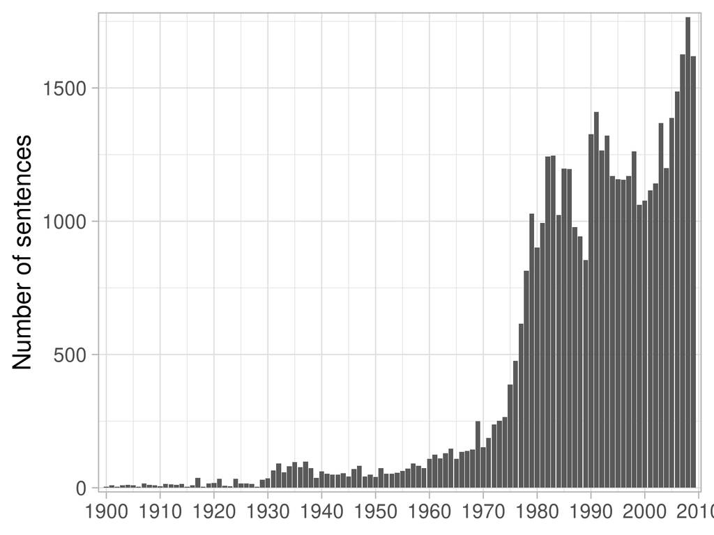

### Closest sentence from ‘rational’ and ‘rationality’ of the backbone community

| Sentence | Title | Year | Journal | Authors | Words Similarity |
| --- | --- | --- | --- | --- | --- |
| However, we can anticipate that, in our opinion, the results of this paper provide some support for those who are critical toward the rational expectations characterization of rational behavior. | Can people learn rational expectations? - An ‘ecological’ approach | 1994 | Journal of Evolutionary Economics | Sacco P. | 0.839 |
| A rational agent draws on an information set larger than historical prices, and expectations are rational if they depend upon the same things that economic theory suggests determines the variable. | [A Semi-Strong Form Evaluation of the Efficiency of the Hog Futures Market](http://www.jstor.org/stable/1239434) | 1979 | American Journal of Agricultural Economics | Raymond M. Leuthold, Peter A. Hartmann | 0.828 |
| The requirement that agents’ expectations be rational, i.e. | Variations in economic uncertainty and risk premiums on capital assets | 1993 | European Economic Review | Gennotte G. | 0.826 |
| As an alternative to rational expectations bounded rationality models have been proposed. | Consistent expectations equilibria and learning in a stock market | 2002 | Journal of Economic Dynamics and Control | Sögner L. | 0.825 |
| Expectations about a variable are said to be rational if they depend, in the proper way, on the same things that economic theory says actually determine that variable. | [Rational Expectations and the Dynamics of Hyperinflation](http://www.jstor.org/stable/2525924) | 1973 | International Economic Review | Thomas J. Sargent, Neil Wallace | 0.822 |
| Instead of starting off by assuming that agents have rational expectations, we merely see rational expectations as a possible long run outcome of a learning process of boundedly rational agents using … | Informational differences and learning in an asset market with boundedly rational agents | 2008 | Journal of Economic Dynamics and Control | Diks C. | 0.822 |
| solution and thus being eductively stable.1 His analysis revealed that not every rational expectations equilibrium can be justified using the concept of rationalizability. | [Are Rational Expectations Equilibria with Private Information Eductively Stable?](http://www.jstor.org/stable/41795156) | 2004 | Journal of Economics | Maik Heinemann | 0.821 |
| This paper emphasizes the point that supposing agents are more rational, in the sense that they take additional aspects of their inference problem into account, may preclude convergence to rational ex… | Time-varying parameters and nonconvergence to rational expectations under least squares learning | 1992 | Economics Letters | Bullard J. | 0.815 |
| The term “rational expectations” (discussed earlier) refers to rational-choice models with the additional assumption that agents form their expectations and beliefs by optimally processing information… | Rational-choice hermeneutics | 2004 | Journal of Economic Behavior and Organization | Koppl R. | 0.815 |
| While some of these authors have avoided general conclusions, others have suggested that this characteristic non-uniqueness constitutes a serious weakness for the rational expectations hyy:!othesis.’ | On non-uniqueness in rational expectations models. An attempt at perspective | 1983 | Journal of Monetary Economics | McCallum B. | 0.815 |
| Rational expectations (pˆr ) are based on the correct market model accounting for the optimizing choices of all agents involved. | Energy conservation, expectations and uncertainty | 2008 | Energy Economics | Wirl F. | 0.814 |
| Note that, unlike the literature on bounded rationality which investigates the reasons for not following a full rational expectations’ solutions, we examine the effects here. | Asymmetric information and rational expectations: When is it right to be “wrong”? | 2008 | Journal of International Money and Finance | Demertzis M. | 0.814 |
| Thus expectations are assumed to be “rational,” albeit in a limited sense. | [More on the Speed of Adjustment in Inventory Models](http://www.jstor.org/stable/1992386) | 1986 | Journal of Money, Credit and Banking | Alan S. Blinder | 0.814 |
| A rational agent would therefore reject rational expectations (Davidson, 1982- | [What’s so Rational about Rational Expectations? Hyperrationality and the Logical Limits to Neoclassicism](http://www.jstor.org/stable/4538571) | 1997 | Journal of Post Keynesian Economics | Steven Shulman | 0.813 |
| We have now analyzed the two polar cases of pure rational expectations and pure limited rationality. | [Rational Expectations and the Limits of Rationality: An Analysis of Heterogeneity](http://www.jstor.org/stable/1814803) | 1985 | The American Economic Review | John Haltiwanger, Michael Waldman | 0.813 |
| We take as a measure of bounded rationality the difference between the agents’ subjective expectation and the actual expected value of the variable given their information. | Structural stability implies robustness to bounded rationality | 2001 | Journal of Economic Theory | Anderlini L. | 0.812 |
| Alternative formulations, such as the assumption that expectations are naive or generated by some other simple autoregressive form, are inadequate for similar reasons The Rational Expectations Hypothe… | [Rational Expectations in Agricultural Economics Research and Policy Analysis](http://www.jstor.org/stable/1241132) | 1982 | American Journal of Agricultural Economics | Brian S. Fisher | 0.812 |
| We begin our analysis by examining whether expectations are formed rationally. | Two currencies, one model? Evidence from the Wall Street Journal forecast poll | 2009 | Journal of International Financial Markets Institutions and Money | Frenkel M. | 0.811 |
| If one assumes that agents have rational expectations, a stricter condition is being imposed, namely that beliefs are correct2. | [Floating Exchange Rates versus a Monetary Union under Rational Beliefs: The Role of Endogenous Uncertainty](http://www.jstor.org/stable/25055627) | 2003 | Economic Theory | Carsten Krabbe Nielsen | 0.811 |
| Our findings show that whether rational expectations (i.e. | Price stability and volatility in markets with positive and negative expectations feedback: An experimental investigation | 2009 | Journal of Economic Dynamics and Control | Heemeijer P. | 0.811 |
| This is true because a rational expectation must include within it the postulate that the decision maker will behave according to some underlying theory [8]; yet no uniquely best theory here exists fo… | [Rational Expectations of Government Policy: An Application of Newcomb’s Problem](http://www.jstor.org/stable/1058483) | 1982 | Southern Economic Journal | Roman Frydman, Gerald P. O’Driscoll, Jr., Andrew Schotter | 0.811 |

### Closest sentences from ‘rational’ and ‘rationality’ of the HDBSCAN cluster

#### Closes sentences 1_0_1900-1919: gold, silver, quantity_theory, currency, money (1900-1919)

| Sentence | Title | Year | Journal | Authors | Words Similarity |
| --- | --- | --- | --- | --- | --- |
| 1 Reasoning of the same general kind clearly holds good in so far as money is desired as a means of providing security. | [The Value of Money](http://www.jstor.org/stable/1885078) | 1917 | The Quarterly Journal of Economics | A. C. Pigou | 0.642 |
| Here, then, the conditions under which the argument would hold are, first, that the rational element among the bondholders should expect other classes to pay the bulk of the debt to them; secondly, th… | [Fundamental Factors in War Finance](http://www.jstor.org/stable/1821720) | 1917 | Journal of Political Economy | Frank F. Anderson | 0.613 |
| The following explanation is equally plausible for many instances, namely, that the penny ceases to figure as the unit of account in deliberations about expenditure when a man achieves wealth. | [The Utility of Income and Progressive Taxation](http://www.jstor.org/stable/2222207) | 1913 | The Economic Journal | S. J. Chapman | 0.608 |
| 2 This statement is not offered as a complete explanation of the preoccupation o,f the early economists with the problem of the real measure of v alue. | [Some Limitations of the Value Concept](http://www.jstor.org/stable/1883612) | 1911 | The Quarterly Journal of Economics | Allyn A. Young | 0.608 |
| In fine, spending money cannot conceivably be reduced to such system as making money until someone invents a common denominator for money costs, and for all the different kinds and degrees of subjecti… | [The Backward Art of Spending Money](http://www.jstor.org/stable/1827579) | 1912 | The American Economic Review | Wesley C. Mitchell | 0.601 |
| Clear and concise in expression, restrained and dispassionate in spirit, persuasive in argument and conclusive in evidence, the ” Thoughts on the Restriction ” was fitted to become, as it speedily did… | [The Development of the Theory of Money from Adam Smith to David Ricardo](http://www.jstor.org/stable/1883613) | 1911 | The Quarterly Journal of Economics | Jacob H. Hollander | 0.600 |
| In this controversy a crude quantity theory was turned into a political doctrine. | [Social Value and the Theory of Money](http://www.jstor.org/stable/1823155) | 1917 | Journal of Political Economy | Walter Stewart | 0.600 |
| Add to all this the complications involved in deflation with the many injustices that follow contraction in the currency, and still further add the epidemic of medi2eval ideas that is spreading over t… | [Some After-the-War Problems in Agriculture](http://www.jstor.org/stable/3180209) | 1919 | Journal of Farm Economics | G. F. Warren | 0.596 |
| For the present purpose it is sufficient that such trepidation existed, and that it was translated to some extent into economic action. | [Coöperation Among the Mormons](http://www.jstor.org/stable/1883385) | 1917 | The Quarterly Journal of Economics | Hamilton Gardner | 0.593 |
| In the course of their reasoning, however, the lands, houses, and consumable goods, seem to slip out of their memory; and the strain of their argument frequently supposes that all wealth consists in g… | The Present Position of the Doctrine of Free Trade | 1905 | Publications of the American Economic Association | Frank W. Taussig | 0.593 |
| The suggestion proceeds upon the assumption that the world’s standard of value has been established wholly by concerted and arbitrary action, and that the world might just as well have adopted silver,… | [The Situation of the United States at the Close of the European War, with Special Reference to the Gold Supply](http://www.jstor.org/stable/1814781) | 1917 | The American Economic Review | George E. Roberts | 0.593 |

#### Closes sentences 1_0_1920-1929: gold, quantity_theory, currency, gold_standard, credit (1920-1929)

| Sentence | Title | Year | Journal | Authors | Words Similarity |
| --- | --- | --- | --- | --- | --- |
| “Because it thus rationalizes economic life itself, the use of money lays the foundation for a rational theory of that life” (op. | [Price Economics Versus Welfare Economics: Contemporary Opinion](http://www.jstor.org/stable/1803336) | 1920 | The American Economic Review | Frank A. Fetter | 0.711 |
| The most rational conception of the process through which evidences of indebtedness acquire value is that of viewing the creditor as being in possession of a contingent right against the property of t… | [The Quantity Theory Scrutinized](http://www.jstor.org/stable/1822583) | 1921 | Journal of Political Economy | Hugo Bilgram | 0.625 |
| But Dr. Anderson’s argument in the present instance does not rest upon his familiar categories: value as a product of social psychology, the absolute value of goods and money, the intrinsic value of m… | [The Quantity Theory and Price Stabilization](http://www.jstor.org/stable/1806477) | 1929 | The American Economic Review | Arthur F. Burns | 0.598 |
| We continue, of course, to speak of the value of money, but the catallactic meaning we give to this expression, while somewhat abstract, is neither abstruse nor vague. | [A Revaluation of Traditional Economic Theory](http://www.jstor.org/stable/1807500) | 1921 | The American Economic Review | Carl E. Parry | 0.596 |
| It is easy to argue that any attempt even to consider the problems which are suggested by what has been called the “metaphysical” branch of monetary theory is to be rejected once for all as fruitless,… | [Hawtrey’s the Gold Standard in Theory and Practice](http://www.jstor.org/stable/1885369) | 1927 | The Quarterly Journal of Economics | Arthur W. Marget | 0.594 |
| In practice, therefore, the choice which presents itself is not one between a perfect theoretical standard on the one hand and gold with all its imperfections on the other, but between this gold stand… | [British Opinion on the Gold Standard](http://www.jstor.org/stable/1884872) | 1925 | The Quarterly Journal of Economics | W. T. Layton | 0.594 |
| In practical life recognition of the truth of the proposition is of enormous importance, because it explains the fact that private persons and the banks in which private persons pool their immediate r… | [Limitation of Currency or Limitation of Credit?](http://www.jstor.org/stable/2222618) | 1924 | The Economic Journal | Edwin Cannan | 0.594 |
| His idea seems to be that in such cases different persons, “equally competent judges,” would adopt very different, but “equally authoritative,” estimates of the extent to which the value of money has … | [Professor Edgeworth’s View on Index-Numbers](http://www.jstor.org/stable/1882334) | 1924 | The Quarterly Journal of Economics | C. M. Walsh | 0.585 |
| These remarks upon the metaphysics of monetary theory, and upon the nature of the “truth” attainable in that field, have been prompted by a single paragraph in this little book by a writer whose own d… | [Hawtrey’s the Gold Standard in Theory and Practice](http://www.jstor.org/stable/1885369) | 1927 | The Quarterly Journal of Economics | Arthur W. Marget | 0.583 |
| The value of Mr. Hawtrey’s own metaphysics - the importance of which in his own eyes is attested by the fact that a good part of the first of the four chapters in the book under review is devoted to a… | [Hawtrey’s the Gold Standard in Theory and Practice](http://www.jstor.org/stable/1885369) | 1927 | The Quarterly Journal of Economics | Arthur W. Marget | 0.581 |

#### Closes sentences 1_0_1930-1939: quantity_theory, gold, circulation, money, keynes (1930-1939)

| Sentence | Title | Year | Journal | Authors | Words Similarity |
| --- | --- | --- | --- | --- | --- |
| If rational money valuations and rational response to them be postulated, the actual relations and adjustments may be covered by fairly simple general principles. | [Professor Fisher’s Interest Theory: A Case in Point](http://www.jstor.org/stable/1822329) | 1931 | Journal of Political Economy | Frank H. Knight | 0.690 |
| But it gives us a rational expedient to regulate our monetary destiny. | [Some Theoretical Aspects of the Gold Problem](http://www.jstor.org/stable/2548954) | 1937 | Economica | T. Balogh | 0.672 |
| Our doctrine must, if possible, be dressed in a terminology that is understandable to banking executives; it must not be crowded with ultimates when proximate realities will suffice; it must not be fa… | [Reserve Bank Policy and Economic Planning](http://www.jstor.org/stable/52) | 1933 | The American Economic Review | Harold L. Reed | 0.645 |
| It is my purpose here to try to demonstrate that Mr. Boulding’s criterion, that rational behavior implies the maximization of the internal rate of interest, is incorrect. | [Some Aspects of the Pure Theory of Capital](http://www.jstor.org/stable/1884837) | 1937 | The Quarterly Journal of Economics | Paul A. Samuelson | 0.633 |
| In this way quantity and anti-quantity theorists had many a confused melee which might have been avoided if they had o-nly seen that it did not matter two straws whether they said that the value of mo… | [The Future of Gold in Relation to Demand](http://www.jstor.org/stable/2224761) | 1934 | The Economic Journal | Edwin Cannan | 0.631 |
| A reasoning in monetary terms does not prevent any amount of considerations of the ” real ” implications, whenever such considerations may be desirable, e.g. | [Some Notes on the Stockholm Theory of Savings and Investments II](http://www.jstor.org/stable/2225524) | 1937 | The Economic Journal | Bertil Ohlin | 0.630 |
| The other group discards the concept of utility and investigates special problems with concrete measurable concepts.2 Surely such terms as profits, money, costs, etc., suggest concrete hypotheses and … | [Mathematics in Economics](http://www.jstor.org/stable/1231449) | 1937 | Journal of Farm Economics | J. M. Thompson | 0.630 |
| But it may be argued that as the subjective value of money designed to explain the value of money is based ” on certain value of money, though not the one susceptible to explanation by that subjective… | THE SUBJECTIVE THEORY OF VALUE AND THEORIES OF THE VALUE OF MONEY | 1931 | Kyoto University Economic Review | Kei Shibata | 0.628 |
| A more’ practical conception would be that such variations primarily occur on their own account in certain commodity markets ; and in consequence the idea is not acceptable that variations in the stoc… | ON THE QUANTITY THEORY OF GOLD | 1934 | Kyoto University Economic Review | Koji Matsuoka | 0.623 |
| Thus in his analysis he gives to the fluctuations in the quantity of the means of payment the character of hypothetical necessity. | [François Simiand’s Theory of Economic Progress](http://www.jstor.org/stable/2967444) | 1938 | The Review of Economic Studies | Robert Marjolin, G. Jaffé, W. Jaffé | 0.623 |

#### Closes sentences 1_0_1940-1949: keynes, gold, money, quantity_theory, gold_standard (1940-1949)

| Sentence | Title | Year | Journal | Authors | Words Similarity |
| --- | --- | --- | --- | --- | --- |
| The modern tendency to find mental satisfaction in measuring everything by a fixed rational standard, and the way it takes for granted that everything can be related to everything else, certainly rece… | [On the Economic Significance of Culture](http://www.jstor.org/stable/2113261) | 1944 | The Journal of Economic History | Harold A. Innis | 0.733 |
| The less severe limitations do not require the elimination of cash balances, and they are still sufficient for the construction of a determinate and rational economics - at least so long as anticipati… | [Some Fundamentals in Liquidity Theory](http://www.jstor.org/stable/1884572) | 1945 | The Quarterly Journal of Economics | M. Bronfenbrenner | 0.666 |
| They are definitions of rational economic behavior if they state the conditions under which economic agents will maximize their satisfac- 62 We are well aware of the fact that the excess of money inve… | [Liquidity Preference and the Theory of Interest and Money](http://www.jstor.org/stable/1905567) | 1944 | Econometrica | Franco Modigliani | 0.650 |
| “8 It seems doubtful, however, that”non-rational” money-price demands are confined to labor. | [A Note on the Money Wage Problem](http://www.jstor.org/stable/1885642) | 1941 | The Quarterly Journal of Economics | James Tobin | 0.649 |
| Since this conclusion itself seems necessary to the successful integration of the general theories of money and price and to putting both bodies of doctrine “on the same side of the moon,”2 the object… | [Some Fundamentals in Liquidity Theory](http://www.jstor.org/stable/1884572) | 1945 | The Quarterly Journal of Economics | M. Bronfenbrenner | 0.639 |
| “33 Under”static” assumptions money is neutral even without assuming Say’s law, if only people are assumed to behave “rationally”; this is all that the classical theory assumes and needs to assume.34 … | [Liquidity Preference and the Theory of Interest and Money](http://www.jstor.org/stable/1905567) | 1944 | Econometrica | Franco Modigliani | 0.637 |
| It was not wholly consistent to a modern economic mind: the accumulation of specie, for example, is not a rational method of solving the state’s fiscal problems, because the commodity theory of money … | [The Third Century of Mercantilism](http://www.jstor.org/stable/1052572) | 1944 | Southern Economic Journal | William D. Grampp | 0.614 |
| To this extent, the money illusion is riot a r.naiifestation of irrationality, but rather of rationality on the part of the workler. | [Professor Leontief on Lord Keynes](http://www.jstor.org/stable/1882138) | 1949 | The Quarterly Journal of Economics | Ira O. Scott, Jr. | 0.614 |
| In other words, logic is analytical but never selective, as is Keynes’ “practical intuition.” | [J. M. Keynes’ Concept of Economic Science](http://www.jstor.org/stable/1054123) | 1949 | Southern Economic Journal | Allan G. Gruchy | 0.613 |
| Unless special care is exercised and very careful consideration given both to the underlying assumptions and to the complexity of the problem, this reasoning will resemble in a most striking fashion t… | [A Note on Monopoly](http://www.jstor.org/stable/2550119) | 1941 | Economica | P. T. Bauer | 0.612 |

#### Closes sentences 1_1_1950-1959: quantity_theory, keynes, liquidity, money, monetary (1950-1959)

| Sentence | Title | Year | Journal | Authors | Words Similarity |
| --- | --- | --- | --- | --- | --- |
| Rational behaviour presumably also refers to the holding of cash. | [The Rate of Interest and General Equilibrium Analysis](http://www.jstor.org/stable/2227442) | 1955 | The Economic Journal | F. H. Hahn | 0.664 |
| Specifically, in a money economy it is perfectly rational for an individual to react to a proportionate change in all prices and income, inasmuch as such a change affects the real value of the cash ba… | [A Reconsideration of the General Equilibrium Theory of Money](http://www.jstor.org/stable/2296105) | 1950 | The Review of Economic Studies | Don Patinkin | 0.656 |
| Even if universal rationality could be assumed, this relates only to one good in relation to “money” at one point of time. | [Complementarity and the Lowering of Tariffs](http://www.jstor.org/stable/1805500) | 1956 | The American Economic Review | F. V. Meyer | 0.642 |
| To his mind, a money of stable value, i.e., a nearly constant price level, was a prerequisite for rational economic conduct, especially with respect to individuals’ plans or investments for the future… | [Wicksell on Fiscal Reform: Further Comment](http://www.jstor.org/stable/1811350) | 1953 | The American Economic Review | Carl G. Uhr | 0.633 |
| They may also lead to inflation or that it rationalizes conduct on the basis of an as if assumption. | [Professor Levitt on “Investment, Depression, and the Assurance of Prosperity”: A Comment](http://www.jstor.org/stable/2976885) | 1955 | The Journal of Finance | Warren J. Gustus | 0.631 |
| Money offers an immense field for irrational action, for it is an instrument used by the mass of individuals and it rests on confidence sanctioned by habit. | [Irrationality in Economics](http://www.jstor.org/stable/1881874) | 1954 | The Quarterly Journal of Economics | Louis Baudin | 0.626 |
| I refer to the ptoposition that reasonable men should evaluate money in accord with the utility they derive therefrom. | [Exposition of a New Theory on the Measurement of Risk](http://www.jstor.org/stable/1909829) | 1954 | Econometrica | Daniel Bernoulli | 0.621 |
| To us it seems fundamental to the logic and history of central planning that when money flows hinder output plans, planners will not elect to sacrifice the output plans to the monetary mistakes. | [Unemployment in Planned and Capitalist Economies: Reply](http://www.jstor.org/stable/1885852) | 1955 | The Quarterly Journal of Economics | Alfred R. Oxenfeldt, Ernest Van Den Haag | 0.614 |
| While all of this is irrational from the standpoint of the whole society, the individual traders, of course, behaved rationally in exchanging the various types of money at the values given by society … | [Paper Money-A Cycle in Cathay](http://www.jstor.org/stable/2591131) | 1957 | The Economic History Review | Gordon Tullock | 0.610 |
| “48 Viewed in retrospect, it is certainly arguable that the much earlier use of monetary restriction, for example in the immediate post-war period, was highly desirable as an anti-inflationary weapon;… | [Canadian Post-War Monetary Policy, 1946-52](http://www.jstor.org/stable/138599) | 1954 | The Canadian Journal of Economics and Political Science / Revue canadienne d’Economique et de Science politique | R. Craig McIvor, John H. Panabaker | 0.607 |

#### Closes sentences 1_1_1960-1969: reserves, quantity_theory, money, liquidity, money_supply (1960-1969)

| Sentence | Title | Year | Journal | Authors | Words Similarity |
| --- | --- | --- | --- | --- | --- |
| A monetary system implies some rational evaluation of alternative ways of securing a desired end. | Change, Technology and Politics | 1962 | The Punjab University Economist | Sidney C. Sufrin | 0.693 |
| For one can grant that there exists an irrational element in expectations (the element of which Keynes made so much) without conceding that they are so irrational as to be random and therefore incapab… | [Automatists, Hawtreyans, and Keynesians](http://www.jstor.org/stable/1991183) | 1969 | Journal of Money, Credit and Banking | John Hicks | 0.672 |
| This view is based on the assumption that rationing essentially reflects rational behavior and that its application to borrowers is not arbitrary; indeed, it may be completely impersonal. | [Credit Availability, Interest Rates, and Monetary Policy](http://www.jstor.org/stable/1054954) | 1960 | Southern Economic Journal | Jack Guttentag | 0.667 |
| There is no doubt much to be said for this view; but before concluding that problems of reserve adequacy are more appropriately discussed by psychiatrists than economists, we must see if any of the re… | [The Present State of International Liquidity Theory](http://www.jstor.org/stable/1831844) | 1968 | The American Economic Review | Robert Clower, Richard Lipsey | 0.652 |
| However, this consideration signifies that the logic of rational lender behavior | [Credit Risk and Credit Rationing](http://www.jstor.org/stable/1884253) | 1960 | The Quarterly Journal of Economics | Donald R. Hodgman | 0.652 |
| However feeble one may regard these attempts, they imply that the demand for money is not a result of frictions or institutional considerations alone but of a decision-making process; and this is the … | [Neoclassical Monetary Theory](http://www.jstor.org/stable/2325639) | 1960 | The Journal of Finance | Marshall Kaplan | 0.647 |
| Thus, just because this analysis agrees with Friedman’s on the importance of money and on the stability of the demand for money it leads to a categorical rejection of the notion of entrusting the cont… | [The Monetary Mechanism and Its Interaction with Real Phenomena](http://www.jstor.org/stable/1927150) | 1963 | The Review of Economics and Statistics | Franco Modigliani | 0.643 |
| Provision for possible changes in the value of the monetary unit is another detail; it is excluded here by the assumption of “neutral” money, but its effect is obvious, if the parties can and do exerc… | [Methodology in Economics: Part II](http://www.jstor.org/stable/1055525) | 1961 | Southern Economic Journal | Frank H. Knight | 0.632 |
| By rational behavior we mean that speculators in their search for speculative profits make full use of all available information that has relevance for the prediction of future price (exchange rate) m… | [Speculative Prices as Random Walks: An Analysis of Ten Time Series of Flexible Exchange Rates](http://www.jstor.org/stable/1055642) | 1967 | Southern Economic Journal | William Poole | 0.628 |
| For example, in the long run, money may be the only relevant input, as the other inputs can be purchased. | [Issues and Implications in Current Procedures for Establishing Research Priorities](http://www.jstor.org/stable/1237194) | 1966 | Journal of Farm Economics | R. J. Hildreth | 0.628 |
| Even though this type of theory can “take for granted” financial processes, an important | [Can Monetary Policy Influence the Availability of Credit?](http://www.jstor.org/stable/2977595) | 1966 | The Journal of Finance | A. Dale Tussing | 0.628 |

#### Closes sentences 1_2_1970-1979: rational_expectations, expectations, expectations_hypothesis, forecasts, adaptive_expectations (1970-1979)

| Sentence | Title | Year | Journal | Authors | Words Similarity |
| --- | --- | --- | --- | --- | --- |
| A rational agent draws on an information set larger than historical prices, and expectations are rational if they depend upon the same things that economic theory suggests determines the variable. | [A Semi-Strong Form Evaluation of the Efficiency of the Hog Futures Market](http://www.jstor.org/stable/1239434) | 1979 | American Journal of Agricultural Economics | Raymond M. Leuthold, Peter A. Hartmann | 0.828 |
| Expectations about a variable are said to be rational if they depend, in the proper way, on the same things that economic theory says actually determine that variable. | [Rational Expectations and the Dynamics of Hyperinflation](http://www.jstor.org/stable/2525924) | 1973 | International Economic Review | Thomas J. Sargent, Neil Wallace | 0.822 |
| In Muth’s (1961) sense, expectations of individuals are ‘rational’ when their subjective’ probability distributions of outcomes tend to be distributed about or are unbiased estimates of the ‘objective… | [Money, Efficiency, and Knowledge](http://www.jstor.org/stable/134866) | 1979 | The Canadian Journal of Economics / Revue canadienne d’Economique | T. K. Rymes | 0.807 |
| Following the definition of rationality given above, namely that rational expectations are optimal forecasts conditional on available information, we must make an assumption about the relevant informa… | [Comparing Survey and Rational Measures of Expected Inflation: Forecast Performance and Interest Rate Effects](http://www.jstor.org/stable/1992046) | 1979 | Journal of Money, Credit and Banking | Douglas K. Pearce | 0.802 |
| The expectations mechanism which is derived under this previous concept of ‘rationality’ will satisfy the requirements of our new concept of rationality. | Adaptive and regressive expectations in a rational model of the inflationary process | 1976 | Journal of Monetary Economics | Mussa M. | 0.802 |
| Rather, a model is built in which expectations are ‘rational.’ | Rational expectations and the dynamic structure of macroeconomic models. A critical review | 1978 | Journal of Monetary Economics | Shiller R. | 0.799 |
| Conclusion The equivalence of the expectations mechanisms generated under two alternative concepts of “rationality’ is not really surprising. | Adaptive and regressive expectations in a rational model of the inflationary process | 1976 | Journal of Monetary Economics | Mussa M. | 0.798 |
| Simultaneously with this work, there has been a growing emphasis, particularly in the theoretical literature, that expectation formation should conform to the notion of rationality advanced by Muth [1… | [Comparing Survey and Rational Measures of Expected Inflation: Forecast Performance and Interest Rate Effects](http://www.jstor.org/stable/1992046) | 1979 | Journal of Money, Credit and Banking | Douglas K. Pearce | 0.794 |
| 2Expectations are said to be rational when they conform to the predictions of the relevant economic theory. | [Monetary Policy, Inflation, and Devaluation: A Case Study of the Philippines: Note](http://www.jstor.org/stable/1991839) | 1979 | Journal of Money, Credit and Banking | Nguyên Anh Nga | 0.793 |
| 2We adopt Muth’s [2] definition of rationality, which considers expectations to be rational if they “tend to be distributed, for the same information set, about the prediction of the theory.” | [Rationality of the Michigan Price Expectations Data: Note](http://www.jstor.org/stable/1991539) | 1977 | Journal of Money, Credit and Banking | James Fackler, Bryan Stanhouse | 0.792 |

#### Closes sentences 1_3_1970-1979: monetary_policy, money_supply, monetary, money_stock, money (1970-1979)

| Sentence | Title | Year | Journal | Authors | Words Similarity |
| --- | --- | --- | --- | --- | --- |
| he key element underlying this strong implication of ‘rational’ expec-, for the role of monetary policy is that ‘rational’ expectations, by !G definition, yield predictions of future events which diff… | Optimal expectations and the extreme information assumptions of ‘rational expectations’ macromodels | 1979 | Journal of Monetary Economics | Friedman B. | 0.766 |
| While rational expectation models of the economy have been associated with the proposition that the probability distribution of real variables is independent of the monetary feedback rule, there is an… | Discriminating between rational expectation models. Some evidence | 1978 | Economics Letters | Sheffrin S. | 0.716 |
| However, decisions that may appear irrational when judged by society’s preferences can be consistent with rational behaviour when the perspective is altered by focusing on the central bank’s preferenc… | [The Choice of Monetary Instruments and the Theory of Bureaucracy](http://www.jstor.org/stable/30022666) | 1972 | Public Choice | John F. Chant, Keith Acheson | 0.711 |
| Thus whether or not to change prices becomes a matter of choice, and McCallum shows that under these circumstances the conclusions of rational expectations emerge again, leaving no room for active mon… | [The Inflation-Unemployment Trade-Off: A Critique of the Literature](http://www.jstor.org/stable/2722879) | 1978 | Journal of Economic Literature | Anthony M. Santomero, John J. Seater | 0.708 |
| Only a part of complete rationality is necessary for this result, namely, that part concerning the pattern and impact of monetary policy. | [Evolutionary Economics, Rational Expectations, and Monetary Policy](http://www.jstor.org/stable/4224696) | 1978 | Journal of Economic Issues | William J. Frazer, Jr. | 0.694 |
| 17 Another version of rational expectations based on a simple fixed velocity quantity theory of money gave very poor results in terms of the M. S. S. D. criterion. | [A Test of Expectational Processes using Information from the Capital Markets-the Israeli Case](http://www.jstor.org/stable/2525958) | 1977 | International Economic Review | Alex Cukierman | 0.694 |
| 2 In a later paper [2], Black again insists on the irrationality of such behavior and again argues that rationality, as he defines it, does not ensure a unique price-level path under an active monetar… | [Bootstrap Inflation](http://www.jstor.org/stable/2326399) | 1976 | The Journal of Finance | Leland Yeager | 0.692 |
| The significance of the assumption of ‘rational expectations,’ defined to include the boundary condition (16), is that expectations concerning the fut::lre behaviour of the price level appropriately r… | On the inherent stability of rationally adaptive expectations | 1978 | Journal of Monetary Economics | Mussa M. | 0.688 |
| foundation for the “rational expectations hypothesis” in monetary theory (see, e.g. | [On Models of Money and Perfect Foresight](http://www.jstor.org/stable/2526417) | 1979 | International Economic Review | Guillermo A. Calvo | 0.684 |
| The third part of the paper follows by inquiring into the role of monetary policy in this type of rational expectations model. | Rational expectations and the role of monetary policy | 1976 | Journal of Monetary Economics | Barro R.J. | 0.681 |
| Using another basic assumption of rational expectations, the private sector can be assumed to know both the Federal Reserve’s reaction coefficients and all the information it has; no residual monetary… | [Macro Policy Responses to Price Shocks](http://www.jstor.org/stable/2534306) | 1979 | Brookings Papers on Economic Activity | Edward M. Gramlich | 0.681 |

#### Closes sentences 1_4_1970-1979: inflation, inflationary, inflation_rate, inflationary_expectations, expectations (1970-1979)

| Sentence | Title | Year | Journal | Authors | Words Similarity |
| --- | --- | --- | --- | --- | --- |
| In that case it would be irrational for economic agents to continue to form their price expectations adaptively.12 The rational expectations approach assumes that economic agents use all the informati… | [Price Expectations and the Interest Rate in an Open Economy: Germany, 1960-72](http://www.jstor.org/stable/1992019) | 1977 | Journal of Money, Credit and Banking | Manfred J. M. Neumann | 0.741 |
| Though we have given some consideration to the implications of a model relying on “rational expectations” this should not be construed as an indication that we view such a model per se as an adequate … | [Optimal Demand Policies against Stagflation](http://www.jstor.org/stable/40438706) | 1978 | Weltwirtschaftliches Archiv | Franco Modigliani, Lucas Papademos | 0.728 |
| Rational Expectations The basic proposition of rational expectations is that consistent bias in expected inflation is inconsistent with rationality of economic agents. | [The Inflation-Unemployment Trade-Off: A Critique of the Literature](http://www.jstor.org/stable/2722879) | 1978 | Journal of Economic Literature | Anthony M. Santomero, John J. Seater | 0.726 |
| The growing evidence that the expectations relevant to stock price determination are, in effect, rational serves to cast doubt on the proposition that market forecasts of inflation might not be ration… | [Alternative Models of the Determination of Nominal Interest Rates: The Canadian Evidence](http://www.jstor.org/stable/1991741) | 1976 | Journal of Money, Credit and Banking | James E. Pesando | 0.725 |
| The growing evidence that the expectations relevant to stock price determination are (in effect) rational serves to cast doubt on the proposition that market forecasts of inflation might not be ration… | [A Note on the Rationality of the Livingston Price Expectations](http://www.jstor.org/stable/1830403) | 1975 | Journal of Political Economy | James E. Pesando | 0.722 |
| Further, since - is the ‘rational’ expectations mechanism wheel money holders completely understand the basis for inflation, it follows that this mechanism must also be ‘rational’ in the sense that it… | Adaptive and regressive expectations in a rational model of the inflationary process | 1976 | Journal of Monetary Economics | Mussa M. | 0.715 |
| The hypothesis that expectations are formed “rationally” in the sense described above led the MRE school to construct simple “rational expectations” models which generated “reduced forms” implying tha… | [Optimal Demand Policies against Stagflation](http://www.jstor.org/stable/40438706) | 1978 | Weltwirtschaftliches Archiv | Franco Modigliani, Lucas Papademos | 0.689 |
| If agents assume pt to follow this process, they will be rational in believing that an increase in money this period affects next period’s price level implying, depending on the value of a, expected i… | [Backward and Forward Solutions for Economies with Rational Expectations](http://www.jstor.org/stable/1801627) | 1979 | The American Economic Review | Olivier J. Blanchard | 0.689 |
| This assumption is used for its inherent simplicity; yet Taylor [11] has shown that even in a world of rational expectations, during the transition to rational expectations predictions about the infla… | [Wage and Price Controls in a Dynamic Macro Model](http://www.jstor.org/stable/1913648) | 1978 | Econometrica | Uri M. Possen | 0.679 |
| Models with Rational Expectations Hypothesis In order to incorporate the REH, we assume that people expect inflation based on the information available at time t and that their expectation is essentia… | Rational expectations and the short-run Phillips curves | 1979 | Journal of Macroeconomics | Lahiri K. | 0.676 |

#### Closes sentences 1_15_1980-1989: rational_expectations, expectations, expectations_equilibrium, expectations_models, expectations_hypothesis (1980-1989)

| Sentence | Title | Year | Journal | Authors | Words Similarity |
| --- | --- | --- | --- | --- | --- |
| While some of these authors have avoided general conclusions, others have suggested that this characteristic non-uniqueness constitutes a serious weakness for the rational expectations hyy:!othesis.’ | On non-uniqueness in rational expectations models. An attempt at perspective | 1983 | Journal of Monetary Economics | McCallum B. | 0.815 |
| Thus expectations are assumed to be “rational,” albeit in a limited sense. | [More on the Speed of Adjustment in Inventory Models](http://www.jstor.org/stable/1992386) | 1986 | Journal of Money, Credit and Banking | Alan S. Blinder | 0.814 |
| We have now analyzed the two polar cases of pure rational expectations and pure limited rationality. | [Rational Expectations and the Limits of Rationality: An Analysis of Heterogeneity](http://www.jstor.org/stable/1814803) | 1985 | The American Economic Review | John Haltiwanger, Michael Waldman | 0.813 |
| Alternative formulations, such as the assumption that expectations are naive or generated by some other simple autoregressive form, are inadequate for similar reasons The Rational Expectations Hypothe… | [Rational Expectations in Agricultural Economics Research and Policy Analysis](http://www.jstor.org/stable/1241132) | 1982 | American Journal of Agricultural Economics | Brian S. Fisher | 0.812 |
| This is true because a rational expectation must include within it the postulate that the decision maker will behave according to some underlying theory [8]; yet no uniquely best theory here exists fo… | [Rational Expectations of Government Policy: An Application of Newcomb’s Problem](http://www.jstor.org/stable/1058483) | 1982 | Southern Economic Journal | Roman Frydman, Gerald P. O’Driscoll, Jr., Andrew Schotter | 0.811 |
| Rationality of expectations, or equivalently, capital market efliciency, implies that conditional on c#+*-i, the subjective expectation of R, assessed by the market is equal to the objective expectati… | An integrated view of tests of rationality, market efficiency and the short-run neutrality of monetary policy | 1983 | Journal of Monetary Economics | Abel A. | 0.810 |
| Similarly this analysis shows that the definition of rational expectations as being “expectations formed conditional on all available information” is ambiguous since it may not be possible to define t… | [Some Implications of the Efficient Capital Market Hypothesis](http://www.jstor.org/stable/4537813) | 1983 | Journal of Post Keynesian Economics | Torben M. Andersen | 0.810 |
| Rational expectations models assume an extreme degree of substantive rationality, which exceeds the information-processing capacities of most economic agents. | [Uncertainty, Human Judgment, and Economic Decisions](http://www.jstor.org/stable/4537676) | 1982 | Journal of Post Keynesian Economics | C. Alan Garner | 0.808 |
| Simaan and Cruz (I 973) give an example with two rational expectations equilibria, but there is clearly a conceptual problem in interpreting the rationality of the equilibrium in such cases. | [Oil Prices, Cartels, and the Problem of Dynamic Inconsistency](http://www.jstor.org/stable/2232829) | 1981 | The Economic Journal | D. M. G. Newbery | 0.807 |
| Yet o not impose the assumption that expectations are rational, there to be no reason to assume that the same set of vari;iibl,es belongs ir. | An integrated view of tests of rationality, market efficiency and the short-run neutrality of monetary policy | 1983 | Journal of Monetary Economics | Abel A. | 0.807 |
| Agents’ expectations are assumed to be formed rationally. | The information content of the exchange rate and the stability of real output under alternative exchange-rate regimes | 1983 | Journal of International Money and Finance | Kimbrough K. | 0.807 |